# Analysing Kraken2 data with phyloseq.

## Introduction

In this script, we will explore the imported dataset from Kraken2 using phyloseq.

We will use the data from 002-phyloseq-kraken2.R script (ps.q.agg agglomerated tables at phylum, family, genus, and Species level).

## Load necessary libraries and scripts.

```r
# install.packages(c("tidyverse","ggtext"))
library(phyloseq)
library(tidyverse)
library(ggtext)
library(vegan)
```

## Import the config file.

```r
source(here::here("config/R/config.R"))# config file with global variables
source(here::here("config/R/themes.R"))# config file with themes
```

Load necessary scripts.

```r
source(file.path(util.functions.r,"get_mean_and_sd_relab_from_phyloseq.R"))
source(file.path(util.functions.r,"create_summary_stats.R"))
source(file.path(util.functions.r,"multi_rarefy_phyloseq.R"))
source(file.path(util.functions.r,"get_average_summary_stats.R"))

source(file.path(util.functions.r,"get_unclassified_summary_stats.R"))
source(file.path(util.functions.r,"get_average_unclassified_summary_stats.R"))
source(file.path(util.functions.r,"ggplot_species.R"))
```

Import raw datasets as rds files.

```r
ps.q <- readRDS(file = ps.q.raw.fname)
ps.q.rel <- readRDS(file = ps.q.rel.raw.fname)
custom.md <- readRDS(custom.md.path)%>%
  filter(sequencing_type =="Naked mole-rat whole metagenome sequencing")
gg.labs.name <- "Age group"
```

## Calculating summary statistics.

Load the NMR age metadata.

```r
custom.md.ages<-readRDS(file.path(metadatadir,"custom.md.ages.rds"))%>%
  filter(sequencing_type == "Naked mole-rat whole metagenome sequencing")
pretty.level.names <-names(table(custom.md$agegroup))
names(pretty.level.names)<-names(table(custom.md$agegroup))
```

Setup sample levels for NMR for barplots.

```r
sample.levels<-custom.md.ages%>%
  ungroup()%>%
  select(Sample,age)%>%
  arrange(age)%>%
  distinct()%>%
  mutate(NewSample=paste0(Sample," (",age,")"))%>%
  mutate(Sample=factor(Sample,levels=Sample),
         NewSample=factor(NewSample,levels=NewSample))
```

Agglomerate the `ps.q.filtered` object and convert it into a dataframe with `psmelt()` function. Then, save it in tab-separated format and as an rds object.

```r
melt_phyloseq_and_save <-function (ps, ps.index){
  ps.indexes <- c("Kingdom","Phylum","Class","Order", "Family", "Genus","Species")

  if(ps.index == "OTU"){
    ps.df <- ps %>%
      psmelt()
  }else{
    ps.df <- ps %>%
      tax_glom(ps.index, NArm=FALSE)%>%
      psmelt()
  }

  if(ps.index == "OTU"){
    ps.df <- ps.df %>%
      dplyr::select(all_of(c("OTU","Sample", "Abundance", "class", ps.indexes)))
  }else{
    selected.indexes <- ps.indexes[1:match(ps.index, ps.indexes)] # vector of taxonomic ranks to select
    ps.df <- ps.df %>%
      dplyr::select(all_of(c("Sample", "Abundance", "class", selected.indexes)))
  }
  # Save the tables in TSV format and as an RDS object
  ps.df.fname <- case_when(ps.index =="OTU" ~ ps.q.agg.asv.fname.no_ext,
                           ps.index =="Species" ~ ps.q.agg.species.fname.no_ext,
                           ps.index =="Genus" ~ ps.q.agg.genus.fname.no_ext,
                           ps.index =="Family" ~ps.q.agg.family.fname.no_ext,
                           ps.index =="Phylum" ~ ps.q.agg.phylum.fname.no_ext
  )
  tsv.fname <- file.path(community.composition.tables, paste0(ps.df.fname,".tsv"))
  rda.fname <- file.path(community.composition.rdafiles, paste0(ps.df.fname,".rds"))
  if(!file.exists(tsv.fname)){
    write.table(ps.df,
                file = tsv.fname,
                row.names = F,sep = "\t")
  }
  if(!file.exists(rda.fname)){
    saveRDS(ps.df,
            file = rda.fname)
  }
  return(ps.df)
}

ps.q.agg.asv<-melt_phyloseq_and_save(ps.q, ps.index = "OTU")%>%
  filter(Abundance!=0)%>%
  as_tibble()
ps.q.rel.agg.asv<- ps.q.rel %>%
  psmelt() %>%
  dplyr::select(all_of(c("OTU","Sample", "Abundance", "class",
                         c("Kingdom","Phylum","Class","Order", "Family", "Genus","Species"))))%>%
  filter(Abundance!=0)%>%
  as_tibble()%>%
  rename("RelativeAbundance" = "Abundance")
ps.q.agg.species<-melt_phyloseq_and_save(ps.q, ps.index = "Species")%>%
  filter(Abundance!=0)%>%
  as_tibble()
ps.q.agg.genus <- melt_phyloseq_and_save(ps.q, ps.index = "Genus")%>%
  filter(Abundance!=0)%>%
  as_tibble()
ps.q.agg.family <- melt_phyloseq_and_save(ps.q, ps.index = "Family")%>%
  filter(Abundance!=0)%>%
  as_tibble()
ps.q.agg.phylum<-melt_phyloseq_and_save(ps.q, ps.index = "Phylum")%>%
  filter(Abundance!=0)%>%
  as_tibble()
```

Save filtered phyloseq objects and the contents (OTU table, taxonomy, tree).

```r
if(!file.exists(ps.q.raw.fname)){
  saveRDS(ps.q,
          file = ps.q.raw.fname)
}

if(!file.exists(ps.q.rel.raw.fname)){
  saveRDS(ps.q.rel,
          file = ps.q.rel.raw.fname)
}

if(!file.exists(ps.q.raw.otu_table.fname)){
  saveRDS(ps.q@otu_table %>% as.matrix() %>%as.data.frame(),
          file = ps.q.raw.otu_table.fname)
}
if(!file.exists(ps.q.raw.tax_table.fname)){
  saveRDS(ps.q@tax_table%>% as.matrix() %>%as.data.frame(),
          file = ps.q.raw.tax_table.fname)
}
ps.q.raw.otu_table.fname.tsv <-
  file.path(community.composition.tables,
            gsub("rds", "tsv",basename(ps.q.raw.otu_table.fname))
)
if(!file.exists(ps.q.raw.otu_table.fname.tsv)){
  write.table(ps.q@otu_table%>% as.matrix() %>%as.data.frame() %>% rownames_to_column("OTU"),
              file = ps.q.raw.otu_table.fname.tsv,
              sep = "\t",
              row.names = FALSE)

}
ps.q.raw.tax_table.fname.tsv <-
  file.path(community.composition.tables,
            gsub("rds", "tsv",basename(ps.q.raw.tax_table.fname)))
if(!file.exists(ps.q.raw.tax_table.fname.tsv)){
  write.table(ps.q@tax_table%>% as.matrix() %>%as.data.frame()%>% rownames_to_column("OTU"),
              file = ps.q.raw.tax_table.fname.tsv,
              sep = "\t",
              row.names = FALSE)

}
```

### Calculating summary statistics per host.

The columns are:  
- Total reads  
- Library size (mean Abundance ± SD)  
- Number of ASV per host  
- Number of phyla per host  
- Number of families per host  
- Number of genera per host  
Here, Species are called ASV because the same function is used in the 16S rRNA gene sequencing analysis.

```r
summary.stats <- create_summary_stats(ps.q.agg.asv)
knitr::kable(as.data.frame(summary.stats),format = "simple")
```

| class | TotalSamplesPerHost | TotalReadsPerHost | MeanLibrarySize | SDLibrarySize | ASVPerHost | PhylaPerHost | FamiliesPerHost | GeneraPerHost |
| --- | --- | --- | --- | --- | --- | --- | --- | --- |
| NMR | 11 | 430634351 | 39148577 | 3492314 | 619 | 34 | 185 | 343 |

```r
summary.stats.fname<-file.path(community.composition.tables,
                               "summary-table.tsv")
if(!file.exists(summary.stats.fname)){
  write.table(summary.stats,
              file=summary.stats.fname,
              row.names = F,sep = "\t")
}
```

### Create a summary table for each sample.

```r
n.taxa.per_sample<-ps.q.agg.asv%>%
  group_by(Sample)%>%
  summarise(n_species=n_distinct(Species),
            n_genera=n_distinct(Genus),
            n_families=n_distinct(Family),
            n_phyla=n_distinct(Phylum))
knitr::kable(n.taxa.per_sample,format = "simple")
```

| Sample | n_species | n_genera | n_families | n_phyla |
| --- | --- | --- | --- | --- |
| 2D10 | 287 | 161 | 83 | 16 |
| 2D14 | 321 | 183 | 102 | 23 |
| G14 | 308 | 177 | 91 | 19 |
| G18 | 346 | 186 | 102 | 25 |
| H15 | 365 | 203 | 114 | 22 |
| H21 | 319 | 181 | 102 | 23 |
| H3 | 329 | 192 | 104 | 22 |
| H4 | 317 | 174 | 101 | 21 |
| O15 | 356 | 188 | 103 | 23 |
| Y51b | 322 | 195 | 102 | 21 |
| Y66b | 351 | 207 | 108 | 21 |

```r
n.taxa.per_sample.fname<-file.path(community.composition.tables,
                               "kraken2-n_taxa-per-sample-table.tsv")
if(!file.exists(n.taxa.per_sample.fname)){
  write.table(n.taxa.per_sample,
              file=n.taxa.per_sample.fname,
              row.names = F,sep = "\t")
}
```

## Calculate average, min, max, and SD relative abundances from phyloseq object.

For phyla, families, and genera, no grouping. For species (here, we call them OTU), create a dataframe by age group and total (no grouping).

```r
mean_sd_relab.nmr_no_groups.phyla <- get_mean_and_sd_relab_from_phyloseq(ps.q.rel, "class", "Phylum")
mean_sd_relab.nmr_no_groups.families <- get_mean_and_sd_relab_from_phyloseq(ps.q.rel, "class", "Family")
mean_sd_relab.nmr_no_groups.genera <- get_mean_and_sd_relab_from_phyloseq(ps.q.rel, "class", "Genus")
```

By age group.

```r
mean_sd_relab.nmr_ages.asv <-
  get_mean_and_sd_relab_from_phyloseq(ps.q.rel, "agegroup", "OTU")
```

In total (no grouping).

```r
mean_sd_relab.nmr_no_groups.asv <-
  get_mean_and_sd_relab_from_phyloseq(ps.q.rel, "class", "OTU")

knitr::kable(head(mean_sd_relab.nmr_no_groups.phyla),format = "simple")
```

| class | Kingdom | Phylum | MeanRelativeAbundance | sdRelativeAbundance | minRelativeAbundance | maxRelativeAbundance | n_samples |
| --- | --- | --- | --- | --- | --- | --- | --- |
| NMR | Bacteria | Bacillota | 40.682066 | 12.2238057 | 20.8003012 | 60.132657 | 11 |
| NMR | Eukaryota | Streptophyta | 23.363548 | 3.2931779 | 18.3233954 | 29.118435 | 11 |
| NMR | Bacteria | Bacteroidota | 22.856495 | 9.8706711 | 7.5881662 | 41.637210 | 11 |
| NMR | Bacteria | Actinomycetota | 4.870373 | 1.2582191 | 3.1767290 | 8.269697 | 11 |
| NMR | Bacteria | Pseudomonadota | 3.670396 | 0.3030072 | 3.1864896 | 4.249930 | 11 |
| NMR | Archaea | Euryarchaeota | 2.490599 | 3.3789754 | 0.0265766 | 12.065008 | 11 |

```r
knitr::kable(head(mean_sd_relab.nmr_no_groups.families),format = "simple")
```

| class | Kingdom | Phylum | Family | MeanRelativeAbundance | sdRelativeAbundance | minRelativeAbundance | maxRelativeAbundance | n_samples |
| --- | --- | --- | --- | --- | --- | --- | --- | --- |
| NMR | Bacteria | Bacteroidota | Bacteroidaceae | 16.011616 | 8.441047 | 5.060626 | 30.10842 | 11 |
| NMR | Bacteria | Bacillota | Lachnospiraceae | 14.376708 | 5.547365 | 4.885386 | 26.02276 | 11 |
| NMR | Bacteria | Bacillota | Enterococcaceae | 7.427814 | 2.656070 | 3.408864 | 11.09731 | 11 |
| NMR | Bacteria | Bacteroidota | Tannerellaceae | 5.368870 | 3.116431 | 0.905413 | 11.02561 | 11 |
| NMR | Bacteria | Bacillota | Acidaminococcaceae | 5.159374 | 11.496351 | 0.000000 | 34.31199 | 8 |
| NMR | Eukaryota | Streptophyta | Fabaceae | 4.998068 | 2.979583 | 1.860610 | 10.74997 | 11 |

```r
knitr::kable(head(mean_sd_relab.nmr_no_groups.genera),format = "simple")
```

| class | Kingdom | Phylum | Family | Genus | MeanRelativeAbundance | sdRelativeAbundance | minRelativeAbundance | maxRelativeAbundance | n_samples |
| --- | --- | --- | --- | --- | --- | --- | --- | --- | --- |
| NMR | Bacteria | Bacteroidota | Bacteroidaceae | Bacteroides | 15.975296 | 8.432028 | 5.0466012 | 30.04948 | 11 |
| NMR | Bacteria | Bacillota | Enterococcaceae | Enterococcus | 7.425959 | 2.655508 | 3.4088639 | 11.09731 | 11 |
| NMR | Bacteria | Bacillota | Lachnospiraceae | Anaerostipes | 6.250690 | 3.879774 | 0.1485352 | 14.12265 | 11 |
| NMR | Bacteria | Bacteroidota | Tannerellaceae | Parabacteroides | 5.367006 | 3.116180 | 0.9049122 | 11.02302 | 11 |
| NMR | Bacteria | Bacillota | Acidaminococcaceae | Phascolarctobacterium | 5.159374 | 11.496351 | 0.0000000 | 34.31199 | 8 |
| NMR | Eukaryota | Streptophyta | Convolvulaceae | Ipomoea | 4.394285 | 2.679296 | 1.7091821 | 10.52671 | 11 |

```r
knitr::kable(head(mean_sd_relab.nmr_ages.asv),format = "simple")
```

| agegroup | Kingdom | Phylum | Family | Genus | Species | OTU | MeanRelativeAbundance | sdRelativeAbundance | minRelativeAbundance | maxRelativeAbundance | n_samples |
| --- | --- | --- | --- | --- | --- | --- | --- | --- | --- | --- | --- |
| agegroup0_10 | Bacteria | Bacillota | Enterococcaceae | Enterococcus | Enterococcus_faecium | k__Bacteria\|p__Bacillota\|c__Bacilli\|o__Lactobacillales\|f__Enterococcaceae\|g__Enterococcus\|s__Enterococcus_faecium | 8.916690 | 1.481384 | 6.9493215 | 10.539180 | 4 |
| agegroup0_10 | Bacteria | Bacillota | Lachnospiraceae | Anaerostipes | Anaerostipes_caccae | k__Bacteria\|p__Bacillota\|c__Clostridia\|o__Lachnospirales\|f__Lachnospiraceae\|g__Anaerostipes\|s__Anaerostipes_caccae | 8.636014 | 3.925037 | 4.9429860 | 14.082276 | 4 |
| agegroup0_10 | Bacteria | Bacillota | Peptostreptococcaceae | Clostridioides | Clostridioides_difficile | k__Bacteria\|p__Bacillota\|c__Clostridia\|o__Peptostreptococcales\|f__Peptostreptococcaceae\|g__Clostridioides\|s__Clostridioides_difficile | 6.289186 | 2.746359 | 2.8370679 | 9.550888 | 4 |
| agegroup0_10 | Bacteria | Bacteroidota | Bacteroidaceae | Bacteroides | Bacteroides_thetaiotaomicron | k__Bacteria\|p__Bacteroidota\|c__Bacteroidia\|o__Bacteroidales\|f__Bacteroidaceae\|g__Bacteroides\|s__Bacteroides_thetaiotaomicron | 4.954287 | 3.998748 | 0.3264551 | 10.061379 | 4 |
| agegroup0_10 | Bacteria | Bacteroidota | Bacteroidaceae | Bacteroides | Bacteroides_xylanisolvens | k__Bacteria\|p__Bacteroidota\|c__Bacteroidia\|o__Bacteroidales\|f__Bacteroidaceae\|g__Bacteroides\|s__Bacteroides_xylanisolvens | 4.390999 | 3.408020 | 0.0288592 | 7.456517 | 4 |
| agegroup0_10 | Bacteria | Bacillota | Eubacteriales Order | Intestinimonas | Intestinimonas_butyriciproducens | k__Bacteria\|p__Bacillota\|c__Clostridia\|o__Eubacteriales\|NA\|g__Intestinimonas\|s__Intestinimonas_butyriciproducens | 3.554697 | 1.880238 | 1.4144947 | 5.527708 | 4 |

```r
knitr::kable(head(mean_sd_relab.nmr_no_groups.asv),format = "simple")
```

| class | Kingdom | Phylum | Family | Genus | Species | OTU | MeanRelativeAbundance | sdRelativeAbundance | minRelativeAbundance | maxRelativeAbundance | n_samples |
| --- | --- | --- | --- | --- | --- | --- | --- | --- | --- | --- | --- |
| NMR | Bacteria | Bacteroidota | Bacteroidaceae | Bacteroides | Bacteroides_xylanisolvens | k__Bacteria\|p__Bacteroidota\|c__Bacteroidia\|o__Bacteroidales\|f__Bacteroidaceae\|g__Bacteroides\|s__Bacteroides_xylanisolvens | 8.647850 | 8.297227 | 0.0288592 | 24.80239 | 11 |
| NMR | Bacteria | Bacillota | Enterococcaceae | Enterococcus | Enterococcus_faecium | k__Bacteria\|p__Bacillota\|c__Bacilli\|o__Lactobacillales\|f__Enterococcaceae\|g__Enterococcus\|s__Enterococcus_faecium | 7.080774 | 2.698159 | 3.1880824 | 10.72238 | 11 |
| NMR | Bacteria | Bacillota | Lachnospiraceae | Anaerostipes | Anaerostipes_caccae | k__Bacteria\|p__Bacillota\|c__Clostridia\|o__Lachnospirales\|f__Lachnospiraceae\|g__Anaerostipes\|s__Anaerostipes_caccae | 5.654391 | 3.674711 | 0.1079273 | 14.08228 | 11 |
| NMR | Bacteria | Bacillota | Acidaminococcaceae | Phascolarctobacterium | Phascolarctobacterium_faecium | k__Bacteria\|p__Bacillota\|c__Negativicutes\|o__Acidaminococcales\|f__Acidaminococcaceae\|g__Phascolarctobacterium\|s__Phascolarctobacterium_faecium | 5.155998 | 11.497636 | 0.0000000 | 34.31199 | 3 |
| NMR | Bacteria | Bacteroidota | Bacteroidaceae | Bacteroides | Bacteroides_thetaiotaomicron | k__Bacteria\|p__Bacteroidota\|c__Bacteroidia\|o__Bacteroidales\|f__Bacteroidaceae\|g__Bacteroides\|s__Bacteroides_thetaiotaomicron | 4.563492 | 4.594072 | 0.3264551 | 15.08105 | 11 |
| NMR | Eukaryota | Streptophyta | Convolvulaceae | Ipomoea | Ipomoea_triloba | k__Eukaryota\|p__Streptophyta\|c__Magnoliopsida\|o__Solanales\|f__Convolvulaceae\|g__Ipomoea\|s__Ipomoea_triloba | 4.394285 | 2.679296 | 1.7091821 | 10.52671 | 11 |

Save tables.

```r
mean_sd_relab.nmr_no_groups.phyla.fname <-
  file.path(community.composition.tables,
            "mean-max-min-sd-relab-nmr_no_groups-Phylum.tsv")
if(!file.exists(mean_sd_relab.nmr_no_groups.phyla.fname)){
  write.table(mean_sd_relab.nmr_no_groups.phyla,
              file = mean_sd_relab.nmr_no_groups.phyla.fname,
              row.names = F,sep = "\t")
}

mean_sd_relab.nmr_no_groups.families.fname <-
  file.path(community.composition.tables,
            "mean-max-min-sd-relab-nmr_no_groups-Family.tsv")
if(!file.exists (mean_sd_relab.nmr_no_groups.families.fname)){
  write.table(mean_sd_relab.nmr_no_groups.families,
              file = mean_sd_relab.nmr_no_groups.families.fname,
              row.names = F,sep = "\t")
}

mean_sd_relab.nmr_no_groups.genera.fname <-
  file.path(community.composition.tables,
            "mean-max-min-sd-relab-nmr_no_groups-Genus.tsv")
if(! file.exists (mean_sd_relab.nmr_no_groups.genera.fname)){
  write.table(mean_sd_relab.nmr_no_groups.genera,
              file = mean_sd_relab.nmr_no_groups.genera.fname,
              row.names = F,sep = "\t")
}

mean_sd_relab.nmr_ages.asv.fname <-
  file.path(community.composition.tables,
            "mean-max-min-sd-relab-nmr_ages-Species.tsv")
if(! file.exists (mean_sd_relab.nmr_ages.asv.fname)){
  write.table(mean_sd_relab.nmr_ages.asv,
              file = mean_sd_relab.nmr_ages.asv.fname,
              row.names = F,sep = "\t")
}
mean_sd_relab.nmr_no_groups.asv.fname <-
  file.path(community.composition.tables,
            "mean-max-min-sd-relab-nmr_no_groups-Species.tsv")
if(! file.exists (mean_sd_relab.nmr_no_groups.asv.fname)){
  write.table(mean_sd_relab.nmr_no_groups.asv,
              file = mean_sd_relab.nmr_no_groups.asv.fname,
              row.names = F,sep = "\t")
}
```

First, perform multiple rarefaction:

```r
# print(paste("Rarefying data with", rare.num_samples, "subsamples"))
# rarefied.fname.all <- file.path(community.composition.rdafiles,paste0(
#   paste("ps.q.rare","OTU",paste0(rare.num_samples,"_iter"),
#         paste("NMR",collapse = '-'),sep = "-"),".rds"))
# if(!file.exists(rarefied.fname.all)){
#   ps.q.agg.asv.nmr.rare<-multi_rarefy_phyloseq(ps.q,
#                                                niter = rare.num_samples,
#                                                output.filename.rds =  rarefied.fname.all
#                                                )
# }else{
#   ps.q.agg.asv.nmr.rare<- readRDS(rarefied.fname.all)
# }
```

```r
## Check the most abundant bacterial phyla, families, genera in NMR.
```

Phyla:

```r
mean_sd_relab.nmr_no_groups.phyla %>%
  filter(Kingdom == "Bacteria")%>%
  head()%>%
  knitr::kable(format = "simple")
```

| class | Kingdom | Phylum | MeanRelativeAbundance | sdRelativeAbundance | minRelativeAbundance | maxRelativeAbundance | n_samples |
| --- | --- | --- | --- | --- | --- | --- | --- |
| NMR | Bacteria | Bacillota | 40.6820655 | 12.2238057 | 20.8003012 | 60.1326565 | 11 |
| NMR | Bacteria | Bacteroidota | 22.8564945 | 9.8706711 | 7.5881662 | 41.6372098 | 11 |
| NMR | Bacteria | Actinomycetota | 4.8703733 | 1.2582191 | 3.1767290 | 8.2696969 | 11 |
| NMR | Bacteria | Pseudomonadota | 3.6703964 | 0.3030072 | 3.1864896 | 4.2499305 | 11 |
| NMR | Bacteria | Fibrobacterota | 0.1651987 | 0.1604877 | 0.0017196 | 0.4889666 | 11 |
| NMR | Bacteria | Elusimicrobiota | 0.0712514 | 0.1641982 | 0.0000000 | 0.5600452 | 8 |

Families:

```r
mean_sd_relab.nmr_no_groups.families %>%
  filter(Kingdom == "Bacteria")%>%
  head()%>%
  knitr::kable(format = "simple")
```

| class | Kingdom | Phylum | Family | MeanRelativeAbundance | sdRelativeAbundance | minRelativeAbundance | maxRelativeAbundance | n_samples |
| --- | --- | --- | --- | --- | --- | --- | --- | --- |
| NMR | Bacteria | Bacteroidota | Bacteroidaceae | 16.011616 | 8.441047 | 5.0606261 | 30.108419 | 11 |
| NMR | Bacteria | Bacillota | Lachnospiraceae | 14.376708 | 5.547365 | 4.8853859 | 26.022758 | 11 |
| NMR | Bacteria | Bacillota | Enterococcaceae | 7.427814 | 2.656070 | 3.4088639 | 11.097310 | 11 |
| NMR | Bacteria | Bacteroidota | Tannerellaceae | 5.368870 | 3.116431 | 0.9054130 | 11.025607 | 11 |
| NMR | Bacteria | Bacillota | Acidaminococcaceae | 5.159374 | 11.496351 | 0.0000000 | 34.311994 | 8 |
| NMR | Bacteria | Bacillota | Peptostreptococcaceae | 3.560652 | 2.994174 | 0.3648371 | 9.550888 | 11 |

Genera:

```r
mean_sd_relab.nmr_no_groups.genera %>%
  filter(Kingdom == "Bacteria")%>%
  head()%>%
  knitr::kable(format = "simple")
```

| class | Kingdom | Phylum | Family | Genus | MeanRelativeAbundance | sdRelativeAbundance | minRelativeAbundance | maxRelativeAbundance | n_samples |
| --- | --- | --- | --- | --- | --- | --- | --- | --- | --- |
| NMR | Bacteria | Bacteroidota | Bacteroidaceae | Bacteroides | 15.975296 | 8.432028 | 5.0466012 | 30.049475 | 11 |
| NMR | Bacteria | Bacillota | Enterococcaceae | Enterococcus | 7.425959 | 2.655508 | 3.4088639 | 11.097310 | 11 |
| NMR | Bacteria | Bacillota | Lachnospiraceae | Anaerostipes | 6.250690 | 3.879774 | 0.1485352 | 14.122648 | 11 |
| NMR | Bacteria | Bacteroidota | Tannerellaceae | Parabacteroides | 5.367006 | 3.116180 | 0.9049122 | 11.023018 | 11 |
| NMR | Bacteria | Bacillota | Acidaminococcaceae | Phascolarctobacterium | 5.159374 | 11.496351 | 0.0000000 | 34.311994 | 8 |
| NMR | Bacteria | Bacillota | Peptostreptococcaceae | Clostridioides | 3.560652 | 2.994174 | 0.3648371 | 9.550888 | 11 |

Species:

```r
mean_sd_relab.nmr_no_groups.asv %>%
  filter(Kingdom == "Bacteria")%>%
  head()%>%
  knitr::kable(format = "simple")
```

| class | Kingdom | Phylum | Family | Genus | Species | OTU | MeanRelativeAbundance | sdRelativeAbundance | minRelativeAbundance | maxRelativeAbundance | n_samples |
| --- | --- | --- | --- | --- | --- | --- | --- | --- | --- | --- | --- |
| NMR | Bacteria | Bacteroidota | Bacteroidaceae | Bacteroides | Bacteroides_xylanisolvens | k__Bacteria\|p__Bacteroidota\|c__Bacteroidia\|o__Bacteroidales\|f__Bacteroidaceae\|g__Bacteroides\|s__Bacteroides_xylanisolvens | 8.647850 | 8.297227 | 0.0288592 | 24.80239 | 11 |
| NMR | Bacteria | Bacillota | Enterococcaceae | Enterococcus | Enterococcus_faecium | k__Bacteria\|p__Bacillota\|c__Bacilli\|o__Lactobacillales\|f__Enterococcaceae\|g__Enterococcus\|s__Enterococcus_faecium | 7.080774 | 2.698159 | 3.1880824 | 10.72238 | 11 |
| NMR | Bacteria | Bacillota | Lachnospiraceae | Anaerostipes | Anaerostipes_caccae | k__Bacteria\|p__Bacillota\|c__Clostridia\|o__Lachnospirales\|f__Lachnospiraceae\|g__Anaerostipes\|s__Anaerostipes_caccae | 5.654391 | 3.674711 | 0.1079273 | 14.08228 | 11 |
| NMR | Bacteria | Bacillota | Acidaminococcaceae | Phascolarctobacterium | Phascolarctobacterium_faecium | k__Bacteria\|p__Bacillota\|c__Negativicutes\|o__Acidaminococcales\|f__Acidaminococcaceae\|g__Phascolarctobacterium\|s__Phascolarctobacterium_faecium | 5.155998 | 11.497636 | 0.0000000 | 34.31199 | 3 |
| NMR | Bacteria | Bacteroidota | Bacteroidaceae | Bacteroides | Bacteroides_thetaiotaomicron | k__Bacteria\|p__Bacteroidota\|c__Bacteroidia\|o__Bacteroidales\|f__Bacteroidaceae\|g__Bacteroides\|s__Bacteroides_thetaiotaomicron | 4.563492 | 4.594072 | 0.3264551 | 15.08105 | 11 |
| NMR | Bacteria | Bacteroidota | Tannerellaceae | Parabacteroides | Parabacteroides_distasonis | k__Bacteria\|p__Bacteroidota\|c__Bacteroidia\|o__Bacteroidales\|f__Tannerellaceae\|g__Parabacteroides\|s__Parabacteroides_distasonis | 3.783470 | 2.833600 | 0.5081927 | 10.24094 | 11 |

## Check the most abundant non-bacterial phyla, families, genera in NMR.

Non-bacterial phyla:

```r
mean_sd_relab.nmr_no_groups.phyla.nonbact<-mean_sd_relab.nmr_no_groups.phyla%>%
  filter(Kingdom != "Bacteria")
head(mean_sd_relab.nmr_no_groups.phyla.nonbact)%>%
  knitr::kable(format = "simple")
```

| class | Kingdom | Phylum | MeanRelativeAbundance | sdRelativeAbundance | minRelativeAbundance | maxRelativeAbundance | n_samples |
| --- | --- | --- | --- | --- | --- | --- | --- |
| NMR | Eukaryota | Streptophyta | 23.3635478 | 3.2931779 | 18.3233954 | 29.1184346 | 11 |
| NMR | Archaea | Euryarchaeota | 2.4905986 | 3.3789754 | 0.0265766 | 12.0650075 | 11 |
| NMR | Eukaryota | Ascomycota | 0.9540174 | 0.8389948 | 0.1280452 | 2.4811722 | 11 |
| NMR | Eukaryota | Parabasalia | 0.6564723 | 0.5321252 | 0.1328118 | 1.7745074 | 11 |
| NMR | Eukaryota | Apicomplexa | 0.0254256 | 0.0599956 | 0.0000000 | 0.1924194 | 3 |
| NMR | Eukaryota | Basidiomycota | 0.0149041 | 0.0122868 | 0.0000000 | 0.0285213 | 8 |

Non-bacterial families:

```r
mean_sd_relab.nmr_no_groups.families.nonbact<-mean_sd_relab.nmr_no_groups.families%>%
  filter(Kingdom != "Bacteria")
head(mean_sd_relab.nmr_no_groups.families.nonbact)%>%
  knitr::kable(format = "simple")
```

| class | Kingdom | Phylum | Family | MeanRelativeAbundance | sdRelativeAbundance | minRelativeAbundance | maxRelativeAbundance | n_samples |
| --- | --- | --- | --- | --- | --- | --- | --- | --- |
| NMR | Eukaryota | Streptophyta | Fabaceae | 4.998068 | 2.9795829 | 1.8606097 | 10.749966 | 11 |
| NMR | Eukaryota | Streptophyta | Convolvulaceae | 4.394285 | 2.6792958 | 1.7091821 | 10.526715 | 11 |
| NMR | Eukaryota | Streptophyta | Cupressaceae | 2.609274 | 0.3424485 | 2.3218895 | 3.390330 | 11 |
| NMR | Archaea | Euryarchaeota | Methanobacteriaceae | 2.489866 | 3.3790568 | 0.0261897 | 12.065008 | 11 |
| NMR | Eukaryota | Streptophyta | Proteaceae | 2.112845 | 0.9487269 | 0.9430488 | 3.620957 | 11 |
| NMR | Eukaryota | Streptophyta | Salicaceae | 1.643107 | 0.8245515 | 0.3688666 | 2.984799 | 11 |

Non-bacterial genera:

```r
mean_sd_relab.nmr_no_groups.genera.nonbact<-mean_sd_relab.nmr_no_groups.genera%>%
  filter(Kingdom != "Bacteria")
head(mean_sd_relab.nmr_no_groups.genera.nonbact)%>%
  knitr::kable(format = "simple")
```

| class | Kingdom | Phylum | Family | Genus | MeanRelativeAbundance | sdRelativeAbundance | minRelativeAbundance | maxRelativeAbundance | n_samples |
| --- | --- | --- | --- | --- | --- | --- | --- | --- | --- |
| NMR | Eukaryota | Streptophyta | Convolvulaceae | Ipomoea | 4.394285 | 2.6792958 | 1.7091821 | 10.526715 | 11 |
| NMR | Eukaryota | Streptophyta | Cupressaceae | Cryptomeria | 2.609274 | 0.3424485 | 2.3218895 | 3.390330 | 11 |
| NMR | Archaea | Euryarchaeota | Methanobacteriaceae | Methanobrevibacter | 2.482948 | 3.3575025 | 0.0261897 | 11.988910 | 11 |
| NMR | Eukaryota | Streptophyta | Proteaceae | Macadamia | 2.067874 | 0.9723804 | 0.8940231 | 3.620957 | 11 |
| NMR | Eukaryota | Streptophyta | Salicaceae | Populus | 1.643107 | 0.8245515 | 0.3688666 | 2.984799 | 11 |
| NMR | Eukaryota | Streptophyta | Fabaceae | Glycine | 1.210820 | 2.1318113 | 0.0000000 | 5.712605 | 5 |

Non-bacterial species:

```r
mean_sd_relab.nmr_no_groups.asv.nonbact<-mean_sd_relab.nmr_no_groups.asv%>%
  filter(Kingdom != "Bacteria")
head(mean_sd_relab.nmr_no_groups.asv.nonbact)%>%
  knitr::kable(format = "simple")
```

| class | Kingdom | Phylum | Family | Genus | Species | OTU | MeanRelativeAbundance | sdRelativeAbundance | minRelativeAbundance | maxRelativeAbundance | n_samples |
| --- | --- | --- | --- | --- | --- | --- | --- | --- | --- | --- | --- |
| NMR | Eukaryota | Streptophyta | Convolvulaceae | Ipomoea | Ipomoea_triloba | k__Eukaryota\|p__Streptophyta\|c__Magnoliopsida\|o__Solanales\|f__Convolvulaceae\|g__Ipomoea\|s__Ipomoea_triloba | 4.3942845 | 2.6792958 | 1.7091821 | 10.526715 | 11 |
| NMR | Eukaryota | Streptophyta | Cupressaceae | Cryptomeria | Cryptomeria_japonica | k__Eukaryota\|p__Streptophyta\|c__Pinopsida\|o__Cupressales\|f__Cupressaceae\|g__Cryptomeria\|s__Cryptomeria_japonica | 2.6092737 | 0.3424485 | 2.3218895 | 3.390330 | 11 |
| NMR | Eukaryota | Streptophyta | Proteaceae | Macadamia | Macadamia_integrifolia | k__Eukaryota\|p__Streptophyta\|c__Magnoliopsida\|o__Proteales\|f__Proteaceae\|g__Macadamia\|s__Macadamia_integrifolia | 2.0678735 | 0.9723804 | 0.8940231 | 3.620957 | 11 |
| NMR | Archaea | Euryarchaeota | Methanobacteriaceae | Methanobrevibacter | Methanobrevibacter_sp._AbM4 | k__Archaea\|p__Euryarchaeota\|c__Methanobacteria\|o__Methanobacteriales\|f__Methanobacteriaceae\|g__Methanobrevibacter\|s__Methanobrevibacter_sp._AbM4 | 1.2808634 | 1.6381718 | 0.0261897 | 5.897323 | 11 |
| NMR | Eukaryota | Streptophyta | Fabaceae | Glycine | Glycine_soja | k__Eukaryota\|p__Streptophyta\|c__Magnoliopsida\|o__Fabales\|f__Fabaceae\|g__Glycine\|s__Glycine_soja | 1.2108200 | 2.1318113 | 0.0000000 | 5.712605 | 5 |
| NMR | Eukaryota | Streptophyta | Salicaceae | Populus | Populus_trichocarpa | k__Eukaryota\|p__Streptophyta\|c__Magnoliopsida\|o__Malpighiales\|f__Salicaceae\|g__Populus\|s__Populus_trichocarpa | 0.9575214 | 0.7136691 | 0.3688666 | 2.478445 | 11 |

```r
mean_sd_relab.nmr_no_groups.phyla.nonbact.fname <-file.path(community.composition.tables,
                                                            "mean-max-min-sd-relab-nmr_no_groups-Phylum-nonbact.tsv")

mean_sd_relab.nmr_no_groups.families.nonbact.fname <-file.path(community.composition.tables,
                                                               "mean-max-min-sd-relab-nmr_no_groups-Family-nonbact.tsv")

mean_sd_relab.nmr_no_groups.genera.nonbact.fname <- file.path(community.composition.tables,
                                                              "mean-max-min-sd-relab-nmr_no_groups-Genus-nonbact.tsv")

mean_sd_relab.nmr_no_groups.asv.nonbact.fname <- file.path(community.composition.tables,
                                                           "mean-max-min-sd-relab-nmr_no_groups-OTU-nonbact.tsv")

if(!file.exists(mean_sd_relab.nmr_no_groups.phyla.nonbact.fname)){
  write.table(mean_sd_relab.nmr_no_groups.phyla.nonbact,
              file = mean_sd_relab.nmr_no_groups.phyla.nonbact.fname,
              row.names = F,sep = "\t")
}
if(!file.exists(mean_sd_relab.nmr_no_groups.families.nonbact.fname)){
  write.table(mean_sd_relab.nmr_no_groups.families.nonbact,
              file = mean_sd_relab.nmr_no_groups.families.nonbact.fname,
              row.names = F,sep = "\t")
}
if(!file.exists(mean_sd_relab.nmr_no_groups.genera.nonbact.fname)){
  write.table(mean_sd_relab.nmr_no_groups.genera.nonbact,
              file = mean_sd_relab.nmr_no_groups.genera.nonbact.fname,
              row.names = F,sep = "\t")
}
if(!file.exists(mean_sd_relab.nmr_no_groups.asv.nonbact.fname)){
  write.table(mean_sd_relab.nmr_no_groups.asv.nonbact,
              file = mean_sd_relab.nmr_no_groups.asv.nonbact.fname,
              row.names = F,sep = "\t")
}
```

## Check how much Bacteroidaceae are in NMR.

```r
bacteroidaceae.nmr<-mean_sd_relab.nmr_no_groups.families%>%
  filter(Family=="Bacteroidaceae")
knitr::kable(bacteroidaceae.nmr, format ="simple")
```

| class | Kingdom | Phylum | Family | MeanRelativeAbundance | sdRelativeAbundance | minRelativeAbundance | maxRelativeAbundance | n_samples |
| --- | --- | --- | --- | --- | --- | --- | --- | --- |
| NMR | Bacteria | Bacteroidota | Bacteroidaceae | 16.01162 | 8.441047 | 5.060626 | 30.10842 | 11 |

```r
bacteroidaceae.nmr.fname <-file.path(community.composition.tables,
                                  paste("kraken2",
                                        "bacteroidaceae-nmr-table.tsv",sep="-"))
if(! file.exists (bacteroidaceae.nmr.fname)){
  write.table(bacteroidaceae.nmr,
              file = bacteroidaceae.nmr.fname,
              row.names = F,sep = "\t")
}
```

### Check the most dominant Bacteroidota families in NMR.

```r
bacteroidota.nmr<-mean_sd_relab.nmr_no_groups.families%>%
  filter(Phylum=="Bacteroidota")
knitr::kable(bacteroidota.nmr, format ="simple")
```

| class | Kingdom | Phylum | Family | MeanRelativeAbundance | sdRelativeAbundance | minRelativeAbundance | maxRelativeAbundance | n_samples |
| --- | --- | --- | --- | --- | --- | --- | --- | --- |
| NMR | Bacteria | Bacteroidota | Bacteroidaceae | 16.0116159 | 8.4410466 | 5.0606261 | 30.1084186 | 11 |
| NMR | Bacteria | Bacteroidota | Tannerellaceae | 5.3688697 | 3.1164309 | 0.9054130 | 11.0256075 | 11 |
| NMR | Bacteria | Bacteroidota | Rikenellaceae | 0.7586335 | 0.4449989 | 0.2592412 | 1.4949202 | 11 |
| NMR | Bacteria | Bacteroidota | Prevotellaceae | 0.5325308 | 0.2244371 | 0.1940218 | 0.8997264 | 11 |
| NMR | Bacteria | Bacteroidota | Muribaculaceae | 0.1472213 | 0.0974074 | 0.0551689 | 0.3881501 | 11 |
| NMR | Bacteria | Bacteroidota | Odoribacteraceae | 0.0190002 | 0.0420774 | 0.0000000 | 0.1446391 | 10 |
| NMR | Bacteria | Bacteroidota | Barnesiellaceae | 0.0062140 | 0.0026035 | 0.0020956 | 0.0100583 | 11 |
| NMR | Bacteria | Bacteroidota | Weeksellaceae | 0.0048250 | 0.0068263 | 0.0000000 | 0.0203422 | 5 |
| NMR | Bacteria | Bacteroidota | Flavobacteriaceae | 0.0046063 | 0.0076553 | 0.0000000 | 0.0215975 | 4 |
| NMR | Bacteria | Bacteroidota | Reichenbachiellaceae | 0.0008696 | 0.0003844 | 0.0000000 | 0.0015074 | 10 |
| NMR | Bacteria | Bacteroidota | Porphyromonadaceae | 0.0007361 | 0.0002619 | 0.0003143 | 0.0010198 | 11 |
| NMR | Bacteria | Bacteroidota | Paludibacteraceae | 0.0004715 | 0.0006139 | 0.0000000 | 0.0016192 | 6 |
| NMR | Bacteria | Bacteroidota | Hymenobacteraceae | 0.0003412 | 0.0006157 | 0.0000000 | 0.0015611 | 3 |
| NMR | Bacteria | Bacteroidota | Bacteroidales Order | 0.0002826 | 0.0006671 | 0.0000000 | 0.0022105 | 3 |
| NMR | Bacteria | Bacteroidota | Chitinophagaceae | 0.0001516 | 0.0005029 | 0.0000000 | 0.0016678 | 1 |
| NMR | Bacteria | Bacteroidota | Marinilabiliaceae | 0.0000574 | 0.0001312 | 0.0000000 | 0.0003838 | 2 |
| NMR | Bacteria | Bacteroidota | Sphingobacteriaceae | 0.0000391 | 0.0001087 | 0.0000000 | 0.0003609 | 2 |
| NMR | Bacteria | Bacteroidota | Prolixibacteraceae | 0.0000287 | 0.0000952 | 0.0000000 | 0.0003158 | 1 |

```r
bacteroidota.nmr.fname <-file.path(community.composition.tables,
                                     paste("kraken2",
                                           "bacteroidota-nmr-table.tsv",sep="-"))
if(! file.exists (bacteroidota.nmr.fname)){
  write.table(bacteroidota.nmr,
              file = bacteroidota.nmr.fname,
              row.names = F,sep = "\t")
}
```

## Check Spirochaetaceae, Spirochaetota, and Treponema in NMR.

```r
spirochaetaceae.nmr<-mean_sd_relab.nmr_no_groups.families%>%
  filter(Family=="Spirochaetaceae")
knitr::kable(spirochaetaceae.nmr, format ="simple")
```

| class | Kingdom | Phylum | Family | MeanRelativeAbundance | sdRelativeAbundance | minRelativeAbundance | maxRelativeAbundance | n_samples |
| --- | --- | --- | --- | --- | --- | --- | --- | --- |
| NMR | Bacteria | Spirochaetota | Spirochaetaceae | 2.92e-05 | 6.71e-05 | 0 | 0.0001978 | 2 |

```r
spirochaetota.nmr<-mean_sd_relab.nmr_no_groups.phyla%>%
  filter(Phylum=="Spirochaetota")
knitr::kable(spirochaetota.nmr, format ="simple")
```

| class | Kingdom | Phylum | MeanRelativeAbundance | sdRelativeAbundance | minRelativeAbundance | maxRelativeAbundance | n_samples |
| --- | --- | --- | --- | --- | --- | --- | --- |
| NMR | Bacteria | Spirochaetota | 0.0224319 | 0.0269509 | 0 | 0.0841713 | 10 |

```r
spirochaetaceae.nmr.fname <- file.path(community.composition.tables,
                                       paste("kraken2",
                                             "spirochaetaceae-nmr-table.tsv",sep="-") )
spirochaetota.nmr.fname <- file.path(community.composition.tables,
                                       paste("kraken2",
                                             "spirochaetota-nmr-table.tsv",sep="-") )

if(!file.exists(spirochaetaceae.nmr.fname)){
  write.table(spirochaetaceae.nmr,
              file = spirochaetaceae.nmr.fname,
              row.names = F,sep = "\t")
}
if(!file.exists(spirochaetota.nmr.fname)){
  write.table(spirochaetota.nmr,
              file = spirochaetota.nmr.fname,
              row.names = F,sep = "\t")
}
```

Check the number of Species in Treponema from NMR.

```r
mean_sd_relab.nmr_no_groups.asv%>%
  ungroup()%>%
  filter(Genus=="Treponema",class=="NMR")%>%
  distinct(OTU)%>%
  tally%>%
  knitr::kable(format = "simple")
```

| n |
| --- |
| 10 |

```r
treponema.nmr<-mean_sd_relab.nmr_no_groups.genera%>%
  filter(Genus=="Treponema")
knitr::kable(treponema.nmr, format ="simple")
```

| class | Kingdom | Phylum | Family | Genus | MeanRelativeAbundance | sdRelativeAbundance | minRelativeAbundance | maxRelativeAbundance | n_samples |
| --- | --- | --- | --- | --- | --- | --- | --- | --- | --- |
| NMR | Bacteria | Spirochaetota | Treponemataceae | Treponema | 0.021809 | 0.0268805 | 0 | 0.0841713 | 9 |

```r
treponema.nmr.names<-mean_sd_relab.nmr_no_groups.asv%>%
  filter(Genus=="Treponema")
knitr::kable(treponema.nmr.names, format ="simple")
```

| class | Kingdom | Phylum | Family | Genus | Species | OTU | MeanRelativeAbundance | sdRelativeAbundance | minRelativeAbundance | maxRelativeAbundance | n_samples |
| --- | --- | --- | --- | --- | --- | --- | --- | --- | --- | --- | --- |
| NMR | Bacteria | Spirochaetota | Treponemataceae | Treponema | Treponema_denticola | k__Bacteria\|p__Spirochaetota\|c__Spirochaetia\|o__Spirochaetales\|f__Treponemataceae\|g__Treponema\|s__Treponema_denticola | 0.0122255 | 0.0152929 | 0 | 0.0383772 | 6 |
| NMR | Bacteria | Spirochaetota | Treponemataceae | Treponema | Treponema_succinifaciens | k__Bacteria\|p__Spirochaetota\|c__Spirochaetia\|o__Spirochaetales\|f__Treponemataceae\|g__Treponema\|s__Treponema_succinifaciens | 0.0035980 | 0.0119331 | 0 | 0.0395775 | 1 |
| NMR | Bacteria | Spirochaetota | Treponemataceae | Treponema | Treponema_socranskii | k__Bacteria\|p__Spirochaetota\|c__Spirochaetia\|o__Spirochaetales\|f__Treponemataceae\|g__Treponema\|s__Treponema_socranskii | 0.0011864 | 0.0022392 | 0 | 0.0059638 | 3 |
| NMR | Bacteria | Spirochaetota | Treponemataceae | Treponema | Treponema_brennaborense | k__Bacteria\|p__Spirochaetota\|c__Spirochaetia\|o__Spirochaetales\|f__Treponemataceae\|g__Treponema\|s__Treponema_brennaborense | 0.0010383 | 0.0027974 | 0 | 0.0092385 | 2 |
| NMR | Bacteria | Spirochaetota | Treponemataceae | Treponema | Treponema_pedis | k__Bacteria\|p__Spirochaetota\|c__Spirochaetia\|o__Spirochaetales\|f__Treponemataceae\|g__Treponema\|s__Treponema_pedis | 0.0008930 | 0.0020462 | 0 | 0.0060069 | 2 |
| NMR | Bacteria | Spirochaetota | Treponemataceae | Treponema | Treponema_ruminis | k__Bacteria\|p__Spirochaetota\|c__Spirochaetia\|o__Spirochaetales\|f__Treponemataceae\|g__Treponema\|s__Treponema_ruminis | 0.0008220 | 0.0014180 | 0 | 0.0049113 | 7 |
| NMR | Bacteria | Spirochaetota | Treponemataceae | Treponema | Treponema_peruense | k__Bacteria\|p__Spirochaetota\|c__Spirochaetia\|o__Spirochaetales\|f__Treponemataceae\|g__Treponema\|s__Treponema_peruense | 0.0007219 | 0.0011220 | 0 | 0.0031922 | 4 |
| NMR | Bacteria | Spirochaetota | Treponemataceae | Treponema | Treponema_putidum | k__Bacteria\|p__Spirochaetota\|c__Spirochaetia\|o__Spirochaetales\|f__Treponemataceae\|g__Treponema\|s__Treponema_putidum | 0.0006442 | 0.0021367 | 0 | 0.0070867 | 1 |
| NMR | Bacteria | Spirochaetota | Treponemataceae | Treponema | Treponema_parvum | k__Bacteria\|p__Spirochaetota\|c__Spirochaetia\|o__Spirochaetales\|f__Treponemataceae\|g__Treponema\|s__Treponema_parvum | 0.0005244 | 0.0010686 | 0 | 0.0033756 | 3 |
| NMR | Bacteria | Spirochaetota | Treponemataceae | Treponema | Treponema_vincentii | k__Bacteria\|p__Spirochaetota\|c__Spirochaetia\|o__Spirochaetales\|f__Treponemataceae\|g__Treponema\|s__Treponema_vincentii | 0.0001554 | 0.0005154 | 0 | 0.0017094 | 1 |

```r
treponema.nmr.fname <- file.path(community.composition.tables,
                                 paste("kraken2",
                                       "treponema-nmr-table.tsv",sep="-") )

treponema.nmr.names.fname <- file.path(community.composition.tables,
                                       paste("kraken2",
                                             "treponema-nmr-names.tsv",sep="-") )
if(!file.exists(treponema.nmr.fname)){
  write.table(treponema.nmr,
              file = treponema.nmr.fname,
              row.names = F,sep = "\t")
}
if(!file.exists(treponema.nmr.names.fname)){
  write.table(treponema.nmr.names,
              file = treponema.nmr.names.fname,
              row.names = F,sep = "\t")
}
```

## Analyse sulfur-metabolising bacteria in NMR.

We don’t know where the “sulf” pattern is (Phylum, Order, Genus, or anywhere else), so we use sapply with grepl. https://stackoverflow.com/questions/47941680/grepl-across-multiple-specified-columns

```r
all.ranks<-c("Kingdom", "Phylum", "Class", "Order", "Family","Genus","Species")
sulfur.bact.nmr<-
  ps.q.agg.species[!!rowSums(sapply(ps.q.agg.species[,all.ranks], grepl,
                            pattern = "sulf|thio") ),]%>%
  distinct(Species,.keep_all = T)%>%
  select(all_of(all.ranks))%>%
  inner_join(mean_sd_relab.nmr_no_groups.asv)
head(sulfur.bact.nmr)%>%
  knitr::kable(format = "simple")
```

| Kingdom | Phylum | Class | Order | Family | Genus | Species | class | OTU | MeanRelativeAbundance | sdRelativeAbundance | minRelativeAbundance | maxRelativeAbundance | n_samples |
| --- | --- | --- | --- | --- | --- | --- | --- | --- | --- | --- | --- | --- | --- |
| Bacteria | Pseudomonadota | Gammaproteobacteria | Chromatiales | Ectothiorhodospiraceae | Thioalkalivibrio | Thioalkalivibrio_versutus | NMR | k__Bacteria\|p__Pseudomonadota\|c__Gammaproteobacteria\|o__Chromatiales\|f__Ectothiorhodospiraceae\|g__Thioalkalivibrio\|s__Thioalkalivibrio_versutus | 0.0086914 | 0.0152498 | 0 | 0.0374657 | 3 |
| Bacteria | Thermodesulfobacteriota | Desulfovibrionia | Desulfovibrionales | Desulfovibrionaceae | Desulfovibrio | Desulfovibrio_piger | NMR | k__Bacteria\|p__Thermodesulfobacteriota\|c__Desulfovibrionia\|o__Desulfovibrionales\|f__Desulfovibrionaceae\|g__Desulfovibrio\|s__Desulfovibrio_piger | 0.0030931 | 0.0032614 | 0 | 0.0097499 | 7 |
| Bacteria | Thermodesulfobacteriota | Desulfovibrionia | Desulfovibrionales | Desulfovibrionaceae | Taurinivorans | Taurinivorans_muris | NMR | k__Bacteria\|p__Thermodesulfobacteriota\|c__Desulfovibrionia\|o__Desulfovibrionales\|f__Desulfovibrionaceae\|g__Taurinivorans\|s__Taurinivorans_muris | 0.0008042 | 0.0022070 | 0 | 0.0073123 | 2 |
| Bacteria | Synergistota | Synergistia | Synergistales | Dethiosulfovibrionaceae | Jonquetella | Jonquetella_anthropi | NMR | k__Bacteria\|p__Synergistota\|c__Synergistia\|o__Synergistales\|f__Dethiosulfovibrionaceae\|g__Jonquetella\|s__Jonquetella_anthropi | 0.0006858 | 0.0008508 | 0 | 0.0024127 | 5 |
| Bacteria | Thermodesulfobacteriota | Desulfobulbia | Desulfobulbales | Desulfobulbaceae | Desulfobulbus | Desulfobulbus_oligotrophicus | NMR | k__Bacteria\|p__Thermodesulfobacteriota\|c__Desulfobulbia\|o__Desulfobulbales\|f__Desulfobulbaceae\|g__Desulfobulbus\|s__Desulfobulbus_oligotrophicus | 0.0001801 | 0.0005973 | 0 | 0.0019809 | 1 |
| Archaea | Thermoproteota | Thermoprotei | Desulfurococcales | Desulfurococcaceae | Aeropyrum | Aeropyrum_camini | NMR | k__Archaea\|p__Thermoproteota\|c__Thermoprotei\|o__Desulfurococcales\|f__Desulfurococcaceae\|g__Aeropyrum\|s__Aeropyrum_camini | 0.0001182 | 0.0003693 | 0 | 0.0012309 | 3 |

```r
sulfur.bact.nmr.fname <- file.path(community.composition.tables,
                                   paste("kraken2",
                                         "sulfur.bact.nmr-nmr-table.tsv",sep="-") )
if(!file.exists(sulfur.bact.nmr.fname)){
  write.table(sulfur.bact.nmr,
              file = sulfur.bact.nmr.fname,
              row.names = F,sep = "\t")
}
```

### Plot sulfur metabolising bacteria.

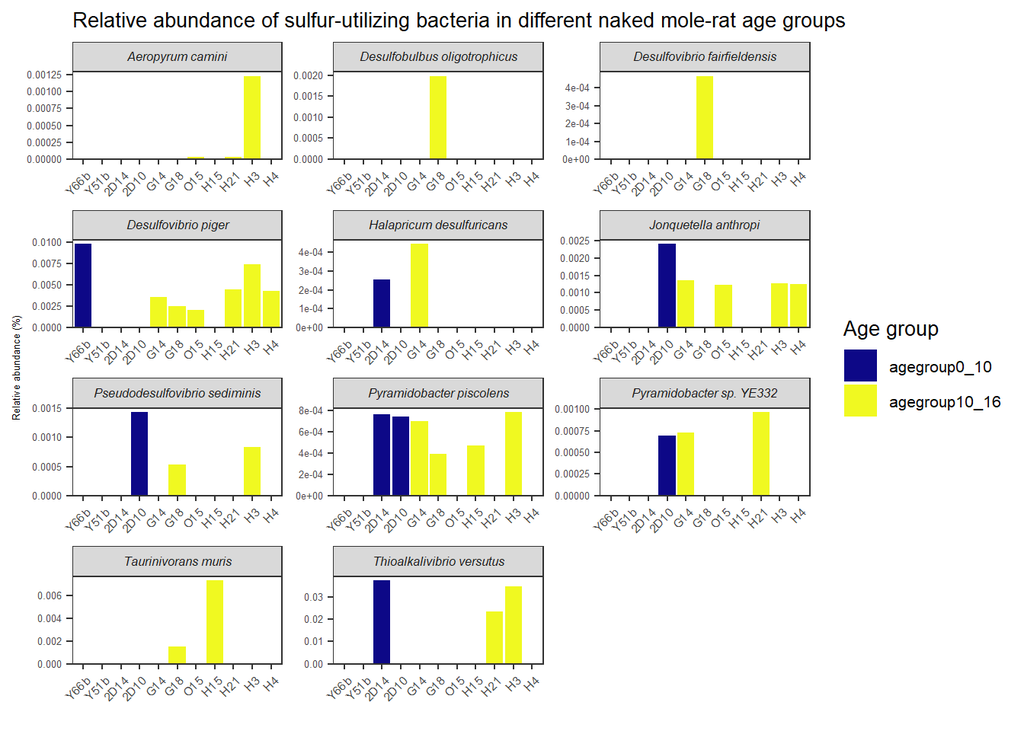

```r
sulfur.bact.plot <- ps.q.rel.agg.asv%>%
  filter(Species %in% sulfur.bact.nmr$Species)%>%
  mutate(Species = factor(Species, levels = sulfur.bact.nmr$Species),
         Species = gsub("_"," ",Species),
         Species = paste0("<i>",Species,"</i>")
  )%>%
  left_join(custom.md[c("Sample","agegroup")])%>%
  mutate(Sample=factor(Sample,levels=sample.levels$Sample))%>%
  group_by_at(c("class","Species"))%>%
  ggplot(aes(x=Sample,
             y=RelativeAbundance,
             fill=factor(agegroup)))+
  geom_bar(stat="identity")+
  facet_wrap(~Species,
             scales = "free",
             ncol = 3)+
  theme_bw()+
  labs(x="",
       y="Relative abundance (%)",
       fill=gg.labs.name)+
  coord_cartesian(expand = c("bottom" = F))+
  scale_color_manual(breaks = unname(pretty.level.names),
                     labels=unname(pretty.level.names))+
  scale_x_discrete(labels=sample.levels$Sample,
                   limits=sample.levels$Sample)+
  # scale_fill_manual(labels=pretty.level.names)+
  scale_fill_viridis_d(option = "C")+
  theme(axis.title.y = element_text(size = 15),
        axis.title = element_text(size = 10),
        axis.text.y = ggtext::element_markdown(size=10),
        axis.text.x = element_text(size=6),
        strip.text.x = ggtext::element_markdown(size=10),
        plot.title = element_text(size = 17),
        legend.text = element_text(size = 10),
        legend.title = element_text(size = 15),
        legend.position = "right",
        panel.grid.minor = element_blank(),
        panel.grid.major = element_blank())
print(sulfur.bact.plot +
        theme(axis.title.y = element_text(size = 5),
              axis.title = element_text(size = 5),
              axis.text.y = ggtext::element_markdown(size=5),
              axis.text.x = element_text(size=6, angle=45, hjust=1),
              strip.text.x = ggtext::element_markdown(size=6),
              plot.title = element_text(size = 10),
              legend.text = element_text(size = 8),
              legend.title = element_text(size = 10),
              legend.position = "right",
              panel.grid.minor = element_blank(),
              panel.grid.major = element_blank())+
        ggtitle(paste0("Relative abundance of sulfur-utilizing bacteria in different naked mole-rat age groups")))
```

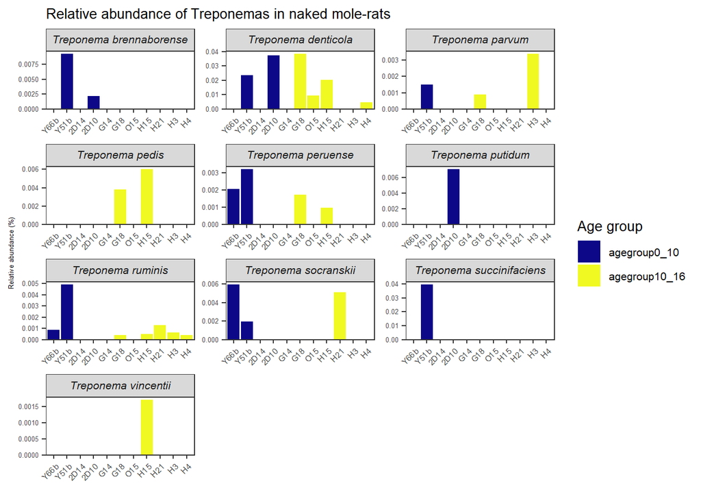

```r
for (image.format in c("png","tiff")){
  ggsave(filename = paste0("sulfur-bacteria-nmr.", image.format),
         path = community.composition.figures,
         plot=sulfur.bact.plot,
         width=11, height=8,units="in",
         dpi=300,device = image.format)
}

treponema.plot<-ps.q.rel.agg.asv%>%
  filter(Genus=="Treponema")%>%
  arrange(Species)%>%
  mutate(Species = factor(Species, levels = unique(Species)),
         Species = gsub("_"," ",Species),
         Species = paste0("<i>",Species,"</i>")
  )%>%
  left_join(custom.md[c("Sample","agegroup")])%>%
  mutate(Sample=factor(Sample,levels=sample.levels$Sample))%>%
  group_by_at(c("class","Species"))%>%
  ggplot(aes(x=Sample,
             y=RelativeAbundance,
             fill=factor(agegroup)))+
  geom_bar(stat="identity")+
  facet_wrap(~Species,
             scales = "free",
             ncol = 3)+
  theme_bw()+
  labs(x="",
       y="Relative abundance (%)",
       fill=gg.labs.name)+
  coord_cartesian(expand = c("bottom" = F))+
  scale_color_manual(breaks = unname(pretty.level.names),
                     labels=unname(pretty.level.names))+
  scale_x_discrete(labels=sample.levels$Sample,
                   limits=sample.levels$Sample)+
  scale_fill_viridis_d(option = "C")+
  theme(axis.title.y = element_text(size = 15),
        axis.title = element_text(size = 10),
        axis.text.y = ggtext::element_markdown(size=10),
        axis.text.x = element_text(size=6),
        strip.text.x = ggtext::element_markdown(size=10),
        plot.title = element_text(size = 17),
        legend.text = element_text(size = 10),
        legend.title = element_text(size = 15),
        legend.position = "right",
        panel.grid.minor = element_blank(),
        panel.grid.major = element_blank())
print(treponema.plot+
        theme(axis.title.y = element_text(size = 5),
              axis.title = element_text(size = 5),
              axis.text.y = ggtext::element_markdown(size=5),
              axis.text.x = element_text(size=6, angle=45, hjust=1),
              strip.text.x = ggtext::element_markdown(size=8),
              plot.title = element_text(size = 10),
              legend.text = element_text(size = 8),
              legend.title = element_text(size = 10),
              legend.position = "right",
              panel.grid.minor = element_blank(),
              panel.grid.major = element_blank())+
        ggtitle(paste0("Relative abundance of Treponemas in naked mole-rats")))
```

```r
for (image.format in c("png","tiff")){
  ggsave(filename = paste0("treponema.sp-nmr.", image.format),
         path = community.composition.figures,
         plot=treponema.plot,
         width=11, height=8,units="in",
         dpi=300,device = image.format)
}
```

## Groups 1, 2, and 3 (**Supplementary figure**).

```r
group1.genera<-c("Faecalibacterium",
                 "Roseburia",
                 "Coprococcus",
                 "Prevotella")
group1.species<-c("Eubacterium_rectale") # Not in our data
group2.increased.genera<-c("Eggerthella",
                           "Bilophila",
                           "Desulfovibrio",
                           "Fusobacterium",
                           "Anaerotruncus",
                           "Streptococcus",
                           "Escherichia")
group2.unhealthy.genera<-c("Eggerthella",
                           "Coprobacillus",
                           "Streptococcus",
                           "Bilophila",
                           "Actinomyces",
                           "Desulfovibrio",
                           "Campylobacter",
                           "Veillonella",
                           "Enterococcus")
group2.unhealthy.families<-c("Atopobiaceae",
                             "Enterobacteriaceae")
group2.unhealthy.species<-c("Bacteroides_fragilis",
                            "Clostridium_hathewayi",
                            "Enterocloster_clostridioformis", #Clostridium_clostridioforme
                            "Enterocloster_bolteae", # Clostridium_bolteae
                            "Clostridium_cindens",
                            "[Ruminococcus]_torques", #Ruminococcus_torques
                            "Mediterraneibacter_gnavus", # Ruminococcus_gnavus
                            "Clostridioides_difficile")

group3.genera<-c("Akkermansia",
                 "Odoribacter",
                 "Butyricimonas",
                 "Butyrivibrio",
                 "Barnesiella",
                 "Oscillospira")
group3.families<-c("Christensenellaceae")
```

Abundances of group 1 genera (decreased with age and associated with healthy aging in humans):

```r
group1.genera
```

```
## [1] "Faecalibacterium" "Roseburia"        "Coprococcus"      "Prevotella"
```

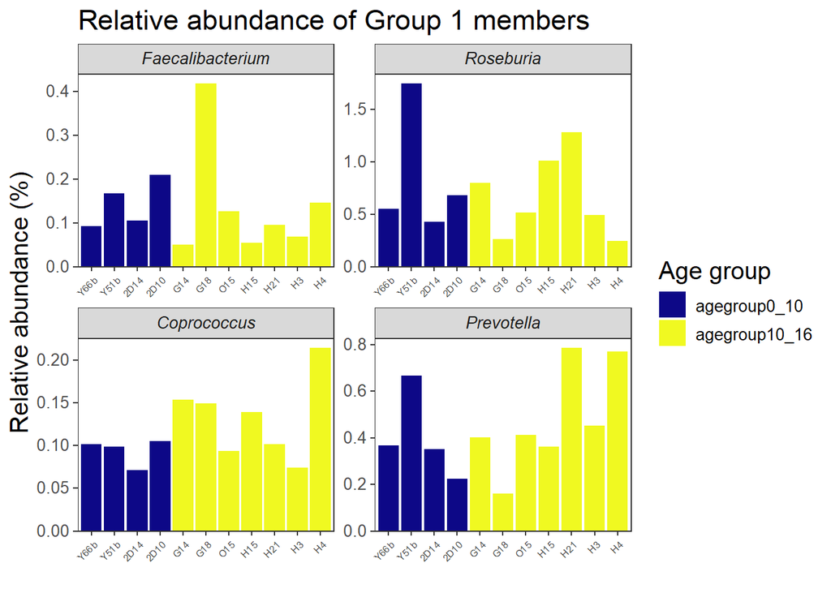

```r
group1.genera.plot<-ggplot_species(group1.genera,
                                   ps.q.rel.agg.asv,
                                   tax.rank="Genus",
                                   sample.order=sample.levels,
                                   group.names = pretty.level.names,
                                   grouping.variable = "agegroup",
                                   metadata.df = custom.md,
                                   ggplot.fill.name = gg.labs.name)
print(group1.genera.plot+
        theme(axis.text.x = element_text(size=6, angle=45, hjust=1))+
        ggtitle(paste0("Relative abundance of Group 1 members"))) # 4 plots
```

```r
group1.species%in%ps.q.rel.agg.asv$Species # no need to plot
```

```
## [1] FALSE
```

Abundances of group 2 genera (increased with age):

```r
group2.increased.genera
```

```
## [1] "Eggerthella"   "Bilophila"     "Desulfovibrio" "Fusobacterium" "Anaerotruncus" "Streptococcus" "Escherichia"
```

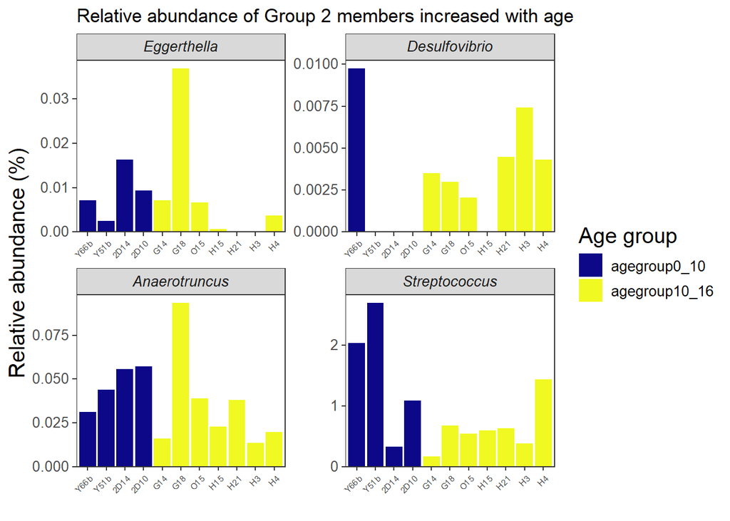

```r
group2.increased.genera.plot<-ggplot_species(taxa.to.plot =group2.increased.genera,
                                             tax.df =ps.q.rel.agg.asv,
                                             tax.rank="Genus",
                                             sample.order=sample.levels,
                                             group.names = pretty.level.names,
                                             grouping.variable = "agegroup",
                                             metadata.df = custom.md,
                                             ggplot.fill.name = gg.labs.name)
print(group2.increased.genera.plot+
        theme(plot.title = element_text(size = 13),
              axis.text.x = element_text(size=6, angle=45, hjust=1))+
        ggtitle(paste0("Relative abundance of Group 2 members increased with age")))
```

Abundances of group 2 genera (associated with unhealthy aging):

```r
group2.unhealthy.genera
```

```
## [1] "Eggerthella"   "Coprobacillus" "Streptococcus" "Bilophila"     "Actinomyces"   "Desulfovibrio" "Campylobacter" "Veillonella"   "Enterococcus"
```

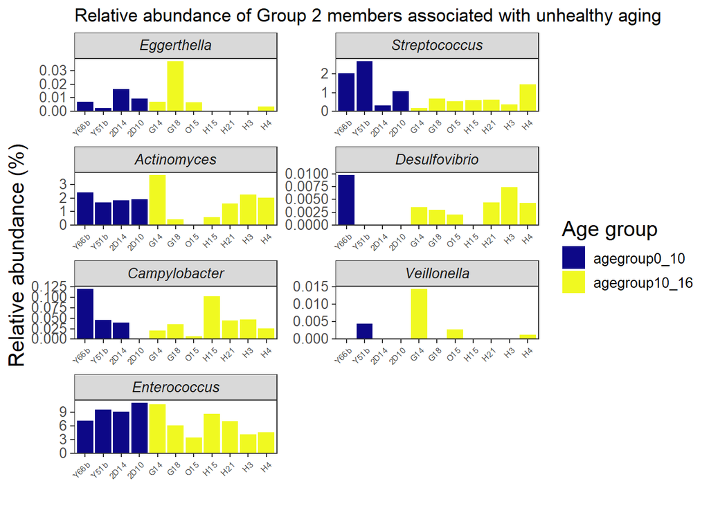

```r
group2.unhealthy.genera.plot<-ggplot_species(taxa.to.plot=group2.unhealthy.genera,
                                              tax.df=ps.q.rel.agg.asv,
                                              tax.rank="Genus",
                                              sample.order=sample.levels,
                                              group.names = pretty.level.names,
                                              grouping.variable = "agegroup",
                                              metadata.df = custom.md,
                                              ggplot.fill.name = gg.labs.name)
print(group2.unhealthy.genera.plot+
        theme(plot.title = element_text(size = 13),
              axis.text.x = element_text(size=6, angle=45, hjust=1))+
  ggtitle(paste0("Relative abundance of Group 2 members associated with unhealthy aging")))
```

Abundances of group 2 families (associated with unhealthy aging):

```r
group2.unhealthy.families
```

```
## [1] "Atopobiaceae"       "Enterobacteriaceae"
```

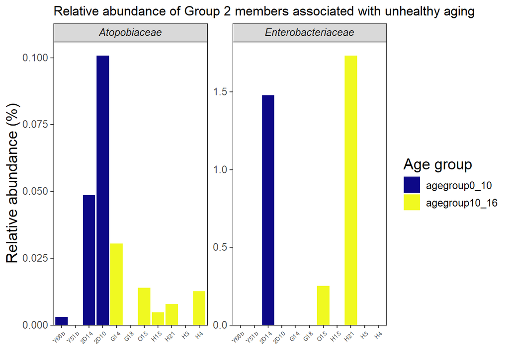

```r
group2.unhealthy.families.plot<-ggplot_species(taxa.to.plot=group2.unhealthy.families,
                                              tax.df=ps.q.rel.agg.asv,
                                              tax.rank="Family",
                                              sample.order=sample.levels,
                                              group.names = pretty.level.names,
                                              grouping.variable = "agegroup",
                                              metadata.df = custom.md,
                                              ggplot.fill.name = gg.labs.name)
print(group2.unhealthy.families.plot+
        theme(plot.title = element_text(size = 13),
              axis.text.x = element_text(size=6, angle=45, hjust=1))+
        ggtitle(paste0("Relative abundance of Group 2 members associated with unhealthy aging")))
```

Abundances of group 2 species (associated with unhealthy aging):

```r
group2.unhealthy.species
```

```
## [1] "Bacteroides_fragilis"           "Clostridium_hathewayi"          "Enterocloster_clostridioformis" "Enterocloster_bolteae"          "Clostridium_cindens"            "[Ruminococcus]_torques"
## [7] "Mediterraneibacter_gnavus"      "Clostridioides_difficile"
```

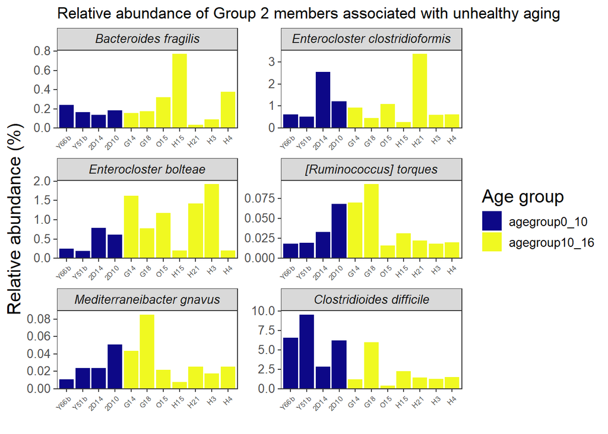

```r
group2.unhealthy.species.plot<-ggplot_species(taxa.to.plot =group2.unhealthy.species,
                                             tax.df = ps.q.rel.agg.asv,
                                              tax.rank="Species",
                                             sample.order=sample.levels,
                                             group.names = pretty.level.names,
                                             grouping.variable = "agegroup",
                                             metadata.df = custom.md,
                                             ggplot.fill.name = gg.labs.name)
print(group2.unhealthy.species.plot+
        theme(plot.title = element_text(size = 13),
              axis.text.x = element_text(size=6, angle=45, hjust=1))+
        ggtitle(paste0("Relative abundance of Group 2 members associated with unhealthy aging")))
```

Abundances of group 3 genera (increased with age and associated with healthy aging):

```r
group3.genera
```

```
## [1] "Akkermansia"   "Odoribacter"   "Butyricimonas" "Butyrivibrio"  "Barnesiella"   "Oscillospira"
```

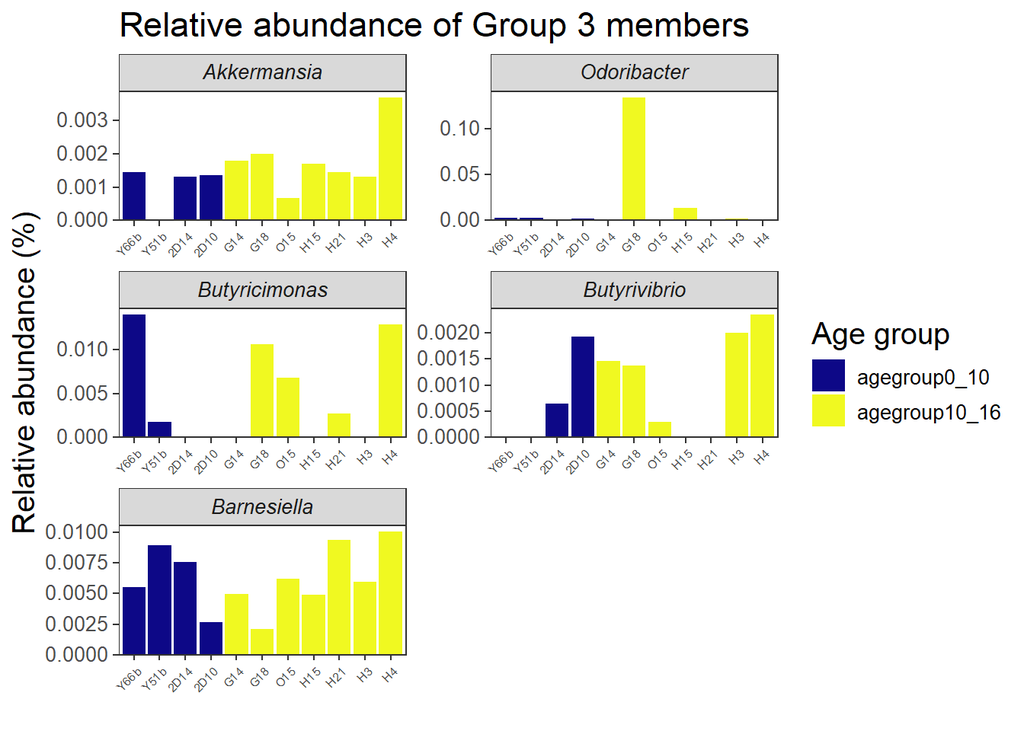

```r
group3.genera.plot<-ggplot_species(taxa.to.plot =group3.genera,
                                    tax.df = ps.q.rel.agg.asv,
                                    tax.rank = "Genus",
                                    sample.order=sample.levels,
                                    group.names = pretty.level.names,
                                    grouping.variable = "agegroup",
                                    metadata.df = custom.md,
                                    ggplot.fill.name = gg.labs.name)
print(group3.genera.plot+
        theme(axis.text.x = element_text(size=6, angle=45, hjust=1))+
        ggtitle(paste0("Relative abundance of Group 3 members")))
```

Abundances of group 3 families (increased with age and associated with healthy aging):

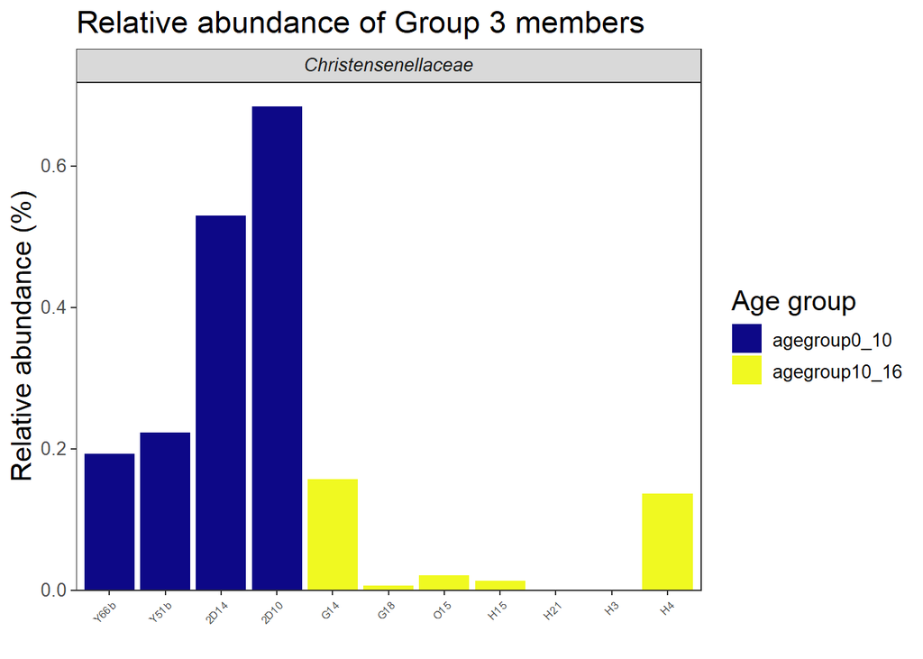

```r
group3.families.plot<-ggplot_species(taxa.to.plot = group3.families,
                                      tax.df = ps.q.rel.agg.asv,
                                    tax.rank = "Family",
                                    sample.order=sample.levels,
                                    group.names = pretty.level.names,
                                    grouping.variable = "agegroup",
                                    metadata.df = custom.md,
                                    ggplot.fill.name = gg.labs.name)
print(group3.families.plot+
        theme(axis.text.x = element_text(size=6, angle=45, hjust=1))+
        ggtitle(paste0("Relative abundance of Group 3 members")))
```

```r
for (image.format in c("png","tiff")){
  ggsave(filename = paste0("group1.genera-nmr.", image.format),
         path = community.composition.figures,
         plot=group1.genera.plot,
         width=10, height=7,units="in",
         dpi=300,device = image.format) # 4 plots
  ggsave(filename = paste0("group2.increased.genera-nmr.",image.format),
         path = community.composition.figures,
         plot=group2.increased.genera.plot,
         width=10, height=7,units="in",
         dpi=300,device = image.format) # 4 plots
  ggsave(filename = paste0("group2.unhealthy.genera-nmr.",image.format),
         path = community.composition.figures,
         plot=group2.unhealthy.genera.plot,
         width=10, height=7,units="in",
         dpi=300,device = image.format) # 7 plots
  ggsave(filename = paste0("group2.unhealthy.families-nmr.",image.format),
         path = community.composition.figures,
         plot = group2.unhealthy.families.plot,
         width=10, height=5,units="in",
         dpi=300,device = image.format)    # 2 plots
  ggsave(filename = paste0("group2.unhealthy.species-nmr.",image.format),
         path = community.composition.figures,
         plot = group2.unhealthy.species.plot,
         width=10, height=8,units="in",
         dpi=300,device = image.format)    # 6 plots
  ggsave(paste0("group3.genera-nmr.", image.format),
         path = community.composition.figures,
         plot= group3.genera.plot ,
         width=10, height=8,units="in",
         dpi=300,device = image.format)    # 5 plots
  ggsave(paste0("group3.families-nmr.", image.format),
         path = community.composition.figures,
         plot = group3.families.plot ,
         width=7, height=5,units="in",
         dpi=300,device = image.format)    # 1 plot

}
```

## Analyse each kingdom in detail.

Number of bacterial species

```r
mean_sd_relab.nmr_no_groups.asv%>%
  filter(Kingdom=="Bacteria")%>%
  nrow
```

```
## [1] 492
```

### Eukaryotes

How many eukaryote species do we have

```r
mean_sd_relab.nmr_no_groups.asv.nonbact%>%
  filter(Kingdom=="Eukaryota")%>%
  distinct(Species)%>%
  tally()
```

```
## # A tibble: 1 × 1
##       n
##   <int>
## 1   100
```

Total abundance of eukaryotes in classified data

```r
mean_sd_relab.nmr_no_groups.asv.nonbact%>%
  ungroup%>%
  filter(Kingdom=="Eukaryota")%>%
  distinct() %>%
  knitr::kable(format = "simple")
```

| class | Kingdom | Phylum | Family | Genus | Species | OTU | MeanRelativeAbundance | sdRelativeAbundance | minRelativeAbundance | maxRelativeAbundance | n_samples |
| --- | --- | --- | --- | --- | --- | --- | --- | --- | --- | --- | --- |
| NMR | Eukaryota | Streptophyta | Convolvulaceae | Ipomoea | Ipomoea_triloba | k__Eukaryota\|p__Streptophyta\|c__Magnoliopsida\|o__Solanales\|f__Convolvulaceae\|g__Ipomoea\|s__Ipomoea_triloba | 4.3942845 | 2.6792958 | 1.7091821 | 10.5267146 | 11 |
| NMR | Eukaryota | Streptophyta | Cupressaceae | Cryptomeria | Cryptomeria_japonica | k__Eukaryota\|p__Streptophyta\|c__Pinopsida\|o__Cupressales\|f__Cupressaceae\|g__Cryptomeria\|s__Cryptomeria_japonica | 2.6092737 | 0.3424485 | 2.3218895 | 3.3903297 | 11 |
| NMR | Eukaryota | Streptophyta | Proteaceae | Macadamia | Macadamia_integrifolia | k__Eukaryota\|p__Streptophyta\|c__Magnoliopsida\|o__Proteales\|f__Proteaceae\|g__Macadamia\|s__Macadamia_integrifolia | 2.0678735 | 0.9723804 | 0.8940231 | 3.6209573 | 11 |
| NMR | Eukaryota | Streptophyta | Fabaceae | Glycine | Glycine_soja | k__Eukaryota\|p__Streptophyta\|c__Magnoliopsida\|o__Fabales\|f__Fabaceae\|g__Glycine\|s__Glycine_soja | 1.2108200 | 2.1318113 | 0.0000000 | 5.7126046 | 5 |
| NMR | Eukaryota | Streptophyta | Salicaceae | Populus | Populus_trichocarpa | k__Eukaryota\|p__Streptophyta\|c__Magnoliopsida\|o__Malpighiales\|f__Salicaceae\|g__Populus\|s__Populus_trichocarpa | 0.9575214 | 0.7136691 | 0.3688666 | 2.4784448 | 11 |
| NMR | Eukaryota | Streptophyta | Fabaceae | Arachis | Arachis_hypogaea | k__Eukaryota\|p__Streptophyta\|c__Magnoliopsida\|o__Fabales\|f__Fabaceae\|g__Arachis\|s__Arachis_hypogaea | 0.7151611 | 1.0374879 | 0.0000000 | 3.3176101 | 5 |
| NMR | Eukaryota | Streptophyta | Salicaceae | Populus | Populus_nigra | k__Eukaryota\|p__Streptophyta\|c__Magnoliopsida\|o__Malpighiales\|f__Salicaceae\|g__Populus\|s__Populus_nigra | 0.6855855 | 0.7582252 | 0.0000000 | 1.9464763 | 6 |
| NMR | Eukaryota | Parabasalia | Trichomonadidae | Trichomonas | Trichomonas_vaginalis | k__Eukaryota\|p__Parabasalia\|NA\|o__Trichomonadida\|f__Trichomonadidae\|g__Trichomonas\|s__Trichomonas_vaginalis | 0.6564723 | 0.5321252 | 0.1328118 | 1.7745074 | 11 |
| NMR | Eukaryota | Streptophyta | Cucurbitaceae | Cucurbita | Cucurbita_pepo | k__Eukaryota\|p__Streptophyta\|c__Magnoliopsida\|o__Cucurbitales\|f__Cucurbitaceae\|g__Cucurbita\|s__Cucurbita_pepo | 0.6400268 | 0.6072243 | 0.0000000 | 1.9084192 | 9 |
| NMR | Eukaryota | Streptophyta | Solanaceae | Capsicum | Capsicum_annuum | k__Eukaryota\|p__Streptophyta\|c__Magnoliopsida\|o__Solanales\|f__Solanaceae\|g__Capsicum\|s__Capsicum_annuum | 0.6317124 | 0.3555059 | 0.2183776 | 1.2555887 | 11 |
| NMR | Eukaryota | Streptophyta | Fabaceae | Medicago | Medicago_truncatula | k__Eukaryota\|p__Streptophyta\|c__Magnoliopsida\|o__Fabales\|f__Fabaceae\|g__Medicago\|s__Medicago_truncatula | 0.5781865 | 0.3389361 | 0.1980142 | 1.2346710 | 11 |
| NMR | Eukaryota | Streptophyta | Poaceae | Triticum | Triticum_dicoccoides | k__Eukaryota\|p__Streptophyta\|c__Magnoliopsida\|o__Poales\|f__Poaceae\|g__Triticum\|s__Triticum_dicoccoides | 0.5543725 | 0.4327733 | 0.0000000 | 1.1225333 | 8 |
| NMR | Eukaryota | Ascomycota | Pichiaceae | Pichia | Pichia_kudriavzevii | k__Eukaryota\|p__Ascomycota\|c__Saccharomycetes\|o__Saccharomycetales\|f__Pichiaceae\|g__Pichia\|s__Pichia_kudriavzevii | 0.5206977 | 0.9007816 | 0.0000000 | 2.3987543 | 8 |
| NMR | Eukaryota | Streptophyta | Fabaceae | Vicia | Vicia_villosa | k__Eukaryota\|p__Streptophyta\|c__Magnoliopsida\|o__Fabales\|f__Fabaceae\|g__Vicia\|s__Vicia_villosa | 0.4741428 | 0.3028619 | 0.0000000 | 0.9873599 | 10 |
| NMR | Eukaryota | Streptophyta | Ximeniaceae | Malania | Malania_oleifera | k__Eukaryota\|p__Streptophyta\|c__Magnoliopsida\|o__Santalales\|f__Ximeniaceae\|g__Malania\|s__Malania_oleifera | 0.4353363 | 0.1918615 | 0.2008671 | 0.7919929 | 11 |
| NMR | Eukaryota | Streptophyta | Fabaceae | Cicer | Cicer_arietinum | k__Eukaryota\|p__Streptophyta\|c__Magnoliopsida\|o__Fabales\|f__Fabaceae\|g__Cicer\|s__Cicer_arietinum | 0.3916369 | 0.4878842 | 0.0000000 | 1.5989451 | 7 |
| NMR | Eukaryota | Streptophyta | Fabaceae | Pisum | Pisum_sativum | k__Eukaryota\|p__Streptophyta\|c__Magnoliopsida\|o__Fabales\|f__Fabaceae\|g__Pisum\|s__Pisum_sativum | 0.3628890 | 0.2299912 | 0.1329909 | 0.8427452 | 11 |
| NMR | Eukaryota | Ascomycota | Aspergillaceae | Aspergillus | Aspergillus_puulaauensis | k__Eukaryota\|p__Ascomycota\|c__Eurotiomycetes\|o__Eurotiales\|f__Aspergillaceae\|g__Aspergillus\|s__Aspergillus_puulaauensis | 0.3496001 | 0.5269957 | 0.0000000 | 1.7242715 | 8 |
| NMR | Eukaryota | Streptophyta | Asteraceae | Lactuca | Lactuca_sativa | k__Eukaryota\|p__Streptophyta\|c__Magnoliopsida\|o__Asterales\|f__Asteraceae\|g__Lactuca\|s__Lactuca_sativa | 0.3475837 | 0.2163442 | 0.0768528 | 0.7642434 | 11 |
| NMR | Eukaryota | Streptophyta | Fabaceae | Cajanus | Cajanus_cajan | k__Eukaryota\|p__Streptophyta\|c__Magnoliopsida\|o__Fabales\|f__Fabaceae\|g__Cajanus\|s__Cajanus_cajan | 0.3137126 | 0.4832510 | 0.0000000 | 1.5356188 | 5 |
| NMR | Eukaryota | Streptophyta | Dioscoreaceae | Dioscorea | Dioscorea_cayenensis | k__Eukaryota\|p__Streptophyta\|c__Magnoliopsida\|o__Dioscoreales\|f__Dioscoreaceae\|g__Dioscorea\|s__Dioscorea_cayenensis | 0.3083730 | 0.2427848 | 0.0000000 | 0.7280405 | 9 |
| NMR | Eukaryota | Streptophyta | Oleaceae | Olea | Olea_europaea | k__Eukaryota\|p__Streptophyta\|c__Magnoliopsida\|o__Lamiales\|f__Oleaceae\|g__Olea\|s__Olea_europaea | 0.2996996 | 0.2736460 | 0.1179943 | 1.0917522 | 11 |
| NMR | Eukaryota | Streptophyta | Fabaceae | Trifolium | Trifolium_pratense | k__Eukaryota\|p__Streptophyta\|c__Magnoliopsida\|o__Fabales\|f__Fabaceae\|g__Trifolium\|s__Trifolium_pratense | 0.2853775 | 0.3922929 | 0.0000000 | 1.0114551 | 5 |
| NMR | Eukaryota | Streptophyta | Fabaceae | Lotus | Lotus_japonicus | k__Eukaryota\|p__Streptophyta\|c__Magnoliopsida\|o__Fabales\|f__Fabaceae\|g__Lotus\|s__Lotus_japonicus | 0.2657827 | 0.2137448 | 0.0000000 | 0.6026839 | 8 |
| NMR | Eukaryota | Streptophyta | Cannabaceae | Humulus | Humulus_lupulus | k__Eukaryota\|p__Streptophyta\|c__Magnoliopsida\|o__Rosales\|f__Cannabaceae\|g__Humulus\|s__Humulus_lupulus | 0.2544362 | 0.2327878 | 0.0000000 | 0.7988457 | 8 |
| NMR | Eukaryota | Streptophyta | Solanaceae | Solanum | Solanum_stenotomum | k__Eukaryota\|p__Streptophyta\|c__Magnoliopsida\|o__Solanales\|f__Solanaceae\|g__Solanum\|s__Solanum_stenotomum | 0.2361178 | 0.2708437 | 0.0000000 | 0.8633769 | 7 |
| NMR | Eukaryota | Streptophyta | Fagaceae | Quercus | Quercus_robur | k__Eukaryota\|p__Streptophyta\|c__Magnoliopsida\|o__Fagales\|f__Fagaceae\|g__Quercus\|s__Quercus_robur | 0.2341839 | 0.2978310 | 0.0000000 | 0.8649622 | 6 |
| NMR | Eukaryota | Streptophyta | Chenopodiaceae | Spinacia | Spinacia_oleracea | k__Eukaryota\|p__Streptophyta\|c__Magnoliopsida\|o__Caryophyllales\|f__Chenopodiaceae\|g__Spinacia\|s__Spinacia_oleracea | 0.2134506 | 0.3845052 | 0.0000000 | 1.0842872 | 3 |
| NMR | Eukaryota | Streptophyta | Ebenaceae | Diospyros | Diospyros_lotus | k__Eukaryota\|p__Streptophyta\|c__Magnoliopsida\|o__Ericales\|f__Ebenaceae\|g__Diospyros\|s__Diospyros_lotus | 0.1954061 | 0.2473246 | 0.0000000 | 0.8612026 | 8 |
| NMR | Eukaryota | Streptophyta | Fabaceae | Vigna | Vigna_radiata | k__Eukaryota\|p__Streptophyta\|c__Magnoliopsida\|o__Fabales\|f__Fabaceae\|g__Vigna\|s__Vigna_radiata | 0.1779137 | 0.2564518 | 0.0000000 | 0.8706590 | 6 |

[output cut: 70 more lines]

Eukaryotic phyla

```r
mean_sd_relab.nmr_no_groups.asv.nonbact%>%
  filter(Kingdom=="Eukaryota")%>%
  group_by(Phylum)%>%
  distinct(Species,.keep_all = T)%>%
  tally()%>%
  knitr::kable(format = "simple")
```

| Phylum | n |
| --- | --- |
| Apicomplexa | 2 |
| Ascomycota | 9 |
| Basidiomycota | 2 |
| Chlorophyta | 1 |
| Fornicata | 1 |
| Parabasalia | 1 |
| Streptophyta | 84 |

Eukaryotic species that aren’t Streptophyta

```r
mean_sd_relab.nmr_no_groups.asv.nonbact%>%
  filter(Kingdom=="Eukaryota",Phylum!="Streptophyta")%>%
  knitr::kable(format = "simple")
```

| class | Kingdom | Phylum | Family | Genus | Species | OTU | MeanRelativeAbundance | sdRelativeAbundance | minRelativeAbundance | maxRelativeAbundance | n_samples |
| --- | --- | --- | --- | --- | --- | --- | --- | --- | --- | --- | --- |
| NMR | Eukaryota | Parabasalia | Trichomonadidae | Trichomonas | Trichomonas_vaginalis | k__Eukaryota\|p__Parabasalia\|NA\|o__Trichomonadida\|f__Trichomonadidae\|g__Trichomonas\|s__Trichomonas_vaginalis | 0.6564723 | 0.5321252 | 0.1328118 | 1.7745074 | 11 |
| NMR | Eukaryota | Ascomycota | Pichiaceae | Pichia | Pichia_kudriavzevii | k__Eukaryota\|p__Ascomycota\|c__Saccharomycetes\|o__Saccharomycetales\|f__Pichiaceae\|g__Pichia\|s__Pichia_kudriavzevii | 0.5206977 | 0.9007816 | 0.0000000 | 2.3987543 | 8 |
| NMR | Eukaryota | Ascomycota | Aspergillaceae | Aspergillus | Aspergillus_puulaauensis | k__Eukaryota\|p__Ascomycota\|c__Eurotiomycetes\|o__Eurotiales\|f__Aspergillaceae\|g__Aspergillus\|s__Aspergillus_puulaauensis | 0.3496001 | 0.5269957 | 0.0000000 | 1.7242715 | 8 |
| NMR | Eukaryota | Ascomycota | Debaryomycetaceae | Candida | Candida_albicans | k__Eukaryota\|p__Ascomycota\|c__Saccharomycetes\|o__Saccharomycetales\|f__Debaryomycetaceae\|g__Candida\|s__Candida_albicans | 0.0329433 | 0.1092607 | 0.0000000 | 0.3623767 | 1 |
| NMR | Eukaryota | Ascomycota | Sclerotiniaceae | Botrytis | Botrytis_cinerea | k__Eukaryota\|p__Ascomycota\|c__Leotiomycetes\|o__Helotiales\|f__Sclerotiniaceae\|g__Botrytis\|s__Botrytis_cinerea | 0.0263571 | 0.0604909 | 0.0000000 | 0.1781600 | 2 |
| NMR | Eukaryota | Apicomplexa | Plasmodiidae | Plasmodium | Plasmodium_knowlesi | k__Eukaryota\|p__Apicomplexa\|c__Aconoidasida\|o__Haemosporida\|f__Plasmodiidae\|g__Plasmodium\|s__Plasmodium_knowlesi | 0.0245241 | 0.0603256 | 0.0000000 | 0.1924194 | 2 |
| NMR | Eukaryota | Ascomycota | Aspergillaceae | Aspergillus | Aspergillus_chevalieri | k__Eukaryota\|p__Ascomycota\|c__Eurotiomycetes\|o__Eurotiales\|f__Aspergillaceae\|g__Aspergillus\|s__Aspergillus_chevalieri | 0.0173051 | 0.0397844 | 0.0000000 | 0.1280452 | 3 |
| NMR | Eukaryota | Basidiomycota | Pucciniaceae | Puccinia | Puccinia_striiformis | k__Eukaryota\|p__Basidiomycota\|c__Pucciniomycetes\|o__Pucciniales\|f__Pucciniaceae\|g__Puccinia\|s__Puccinia_striiformis | 0.0106036 | 0.0117712 | 0.0000000 | 0.0285213 | 6 |
| NMR | Eukaryota | Fornicata | Hexamitidae | Giardia | Giardia_intestinalis | k__Eukaryota\|p__Fornicata\|NA\|o__Diplomonadida\|f__Hexamitidae\|g__Giardia\|s__Giardia_intestinalis | 0.0084750 | 0.0184802 | 0.0000000 | 0.0634814 | 7 |
| NMR | Eukaryota | Chlorophyta | Bathycoccaceae | Ostreococcus | Ostreococcus_sp._‘lucimarinus’ | k__Eukaryota\|p__Chlorophyta\|c__Mamiellophyceae\|o__Mamiellales\|f__Bathycoccaceae\|g__Ostreococcus\|s__Ostreococcus_sp._lucimarinus | 0.0068757 | 0.0228042 | 0.0000000 | 0.0756331 | 1 |
| NMR | Eukaryota | Basidiomycota | Pucciniaceae | Puccinia | Puccinia_triticina | k__Eukaryota\|p__Basidiomycota\|c__Pucciniomycetes\|o__Pucciniales\|f__Pucciniaceae\|g__Puccinia\|s__Puccinia_triticina | 0.0043004 | 0.0066941 | 0.0000000 | 0.0180182 | 4 |
| NMR | Eukaryota | Ascomycota | Schizosaccharomycetaceae | Schizosaccharomyces | Schizosaccharomyces_pombe | k__Eukaryota\|p__Ascomycota\|c__Schizosaccharomycetes\|o__Schizosaccharomycetales\|f__Schizosaccharomycetaceae\|g__Schizosaccharomyces\|s__Schizosaccharomyces_pombe | 0.0034099 | 0.0060928 | 0.0000000 | 0.0169310 | 3 |
| NMR | Eukaryota | Ascomycota | Mycosphaerellaceae | Zymoseptoria | Zymoseptoria_tritici | k__Eukaryota\|p__Ascomycota\|c__Dothideomycetes\|o__Mycosphaerellales\|f__Mycosphaerellaceae\|g__Zymoseptoria\|s__Zymoseptoria_tritici | 0.0025170 | 0.0056850 | 0.0000000 | 0.0160337 | 2 |
| NMR | Eukaryota | Apicomplexa | Sarcocystidae | Neospora | Neospora_caninum | k__Eukaryota\|p__Apicomplexa\|c__Conoidasida\|o__Eucoccidiorida\|f__Sarcocystidae\|g__Neospora\|s__Neospora_caninum | 0.0009016 | 0.0029902 | 0.0000000 | 0.0099174 | 1 |
| NMR | Eukaryota | Ascomycota | Debaryomycetaceae | Debaryomyces | Debaryomyces_hansenii | k__Eukaryota\|p__Ascomycota\|c__Saccharomycetes\|o__Saccharomycetales\|f__Debaryomycetaceae\|g__Debaryomyces\|s__Debaryomyces_hansenii | 0.0008571 | 0.0028426 | 0.0000000 | 0.0094279 | 1 |
| NMR | Eukaryota | Ascomycota | Dipodascaceae | Yarrowia | Yarrowia_lipolytica | k__Eukaryota\|p__Ascomycota\|c__Saccharomycetes\|o__Saccharomycetales\|f__Dipodascaceae\|g__Yarrowia\|s__Yarrowia_lipolytica | 0.0003299 | 0.0010942 | 0.0000000 | 0.0036289 | 1 |

### 13.2 Archaea

How many archaea do we have

```r
mean_sd_relab.nmr_no_groups.asv%>%
  filter(Kingdom=="Archaea")%>%
  distinct(Species)%>%
  tally()
```

```
## # A tibble: 1 × 1
##       n
##   <int>
## 1    15
```

Total abundance of archaea in classified data

```r
mean_sd_relab.nmr_no_groups.asv.nonbact%>%
  ungroup%>%
  filter(Kingdom=="Archaea")%>%
  distinct()%>%
  knitr::kable(format = "simple")
```

| class | Kingdom | Phylum | Family | Genus | Species | OTU | MeanRelativeAbundance | sdRelativeAbundance | minRelativeAbundance | maxRelativeAbundance | n_samples |
| --- | --- | --- | --- | --- | --- | --- | --- | --- | --- | --- | --- |
| NMR | Archaea | Euryarchaeota | Methanobacteriaceae | Methanobrevibacter | Methanobrevibacter_sp._AbM4 | k__Archaea\|p__Euryarchaeota\|c__Methanobacteria\|o__Methanobacteriales\|f__Methanobacteriaceae\|g__Methanobrevibacter\|s__Methanobrevibacter_sp._AbM4 | 1.2808634 | 1.6381718 | 0.0261897 | 5.8973226 | 11 |
| NMR | Archaea | Euryarchaeota | Methanobacteriaceae | Methanobrevibacter | Methanobrevibacter_millerae | k__Archaea\|p__Euryarchaeota\|c__Methanobacteria\|o__Methanobacteriales\|f__Methanobacteriaceae\|g__Methanobrevibacter\|s__Methanobrevibacter_millerae | 0.2749037 | 0.3953089 | 0.0000000 | 1.3942289 | 10 |
| NMR | Archaea | Euryarchaeota | Methanobacteriaceae | Methanobrevibacter | Methanobrevibacter_ruminantium | k__Archaea\|p__Euryarchaeota\|c__Methanobacteria\|o__Methanobacteriales\|f__Methanobacteriaceae\|g__Methanobrevibacter\|s__Methanobrevibacter_ruminantium | 0.2685322 | 0.3095590 | 0.0000000 | 1.1253462 | 10 |
| NMR | Archaea | Euryarchaeota | Methanobacteriaceae | Methanobrevibacter | Methanobrevibacter_olleyae | k__Archaea\|p__Euryarchaeota\|c__Methanobacteria\|o__Methanobacteriales\|f__Methanobacteriaceae\|g__Methanobrevibacter\|s__Methanobrevibacter_olleyae | 0.2068656 | 0.3532260 | 0.0000000 | 1.1910172 | 7 |
| NMR | Archaea | Euryarchaeota | Methanobacteriaceae | Methanobrevibacter | Methanobrevibacter_smithii | k__Archaea\|p__Euryarchaeota\|c__Methanobacteria\|o__Methanobacteriales\|f__Methanobacteriaceae\|g__Methanobrevibacter\|s__Methanobrevibacter_smithii | 0.1641641 | 0.2581924 | 0.0000000 | 0.8944981 | 9 |
| NMR | Archaea | Euryarchaeota | Methanobacteriaceae | Methanobrevibacter | Methanobrevibacter_arboriphilus | k__Archaea\|p__Euryarchaeota\|c__Methanobacteria\|o__Methanobacteriales\|f__Methanobacteriaceae\|g__Methanobrevibacter\|s__Methanobrevibacter_arboriphilus | 0.1226819 | 0.1979728 | 0.0000000 | 0.6511967 | 6 |
| NMR | Archaea | Euryarchaeota | Methanobacteriaceae | Methanobrevibacter | Methanobrevibacter_sp._YE315 | k__Archaea\|p__Euryarchaeota\|c__Methanobacteria\|o__Methanobacteriales\|f__Methanobacteriaceae\|g__Methanobrevibacter\|s__Methanobrevibacter_sp._YE315 | 0.0923706 | 0.1405313 | 0.0000000 | 0.4923608 | 10 |
| NMR | Archaea | Euryarchaeota | Methanobacteriaceae | Methanobrevibacter | Methanobrevibacter_sp._TLL-48-HuF1 | k__Archaea\|p__Euryarchaeota\|c__Methanobacteria\|o__Methanobacteriales\|f__Methanobacteriaceae\|g__Methanobrevibacter\|s__Methanobrevibacter_sp._TLL-48-HuF1 | 0.0725664 | 0.0968016 | 0.0000000 | 0.3429399 | 9 |
| NMR | Archaea | Euryarchaeota | Methanobacteriaceae | Methanosphaera | Methanosphaera_stadtmanae | k__Archaea\|p__Euryarchaeota\|c__Methanobacteria\|o__Methanobacteriales\|f__Methanobacteriaceae\|g__Methanosphaera\|s__Methanosphaera_stadtmanae | 0.0069179 | 0.0229441 | 0.0000000 | 0.0760971 | 1 |
| NMR | Archaea | Nitrososphaerota | Nitrosopumilaceae | Nitrosomarinus | Candidatus_Nitrosomarinus_catalina | k__Archaea\|p__Nitrososphaerota\|c__Nitrososphaeria\|o__Nitrosopumilales\|f__Nitrosopumilaceae\|g__Nitrosomarinus\|s__Candidatus_Nitrosomarinus_catalina | 0.0020272 | 0.0059048 | 0.0000000 | 0.0196714 | 2 |
| NMR | Archaea | Euryarchaeota | Haloarculaceae | Halomicroarcula | Halomicroarcula_marina | k__Archaea\|p__Euryarchaeota\|c__Halobacteria\|o__Halobacteriales\|f__Haloarculaceae\|g__Halomicroarcula\|s__Halomicroarcula_marina | 0.0006524 | 0.0011282 | 0.0000000 | 0.0037712 | 5 |
| NMR | Archaea | Candidatus_Thermoplasmatota | Methanomassiliicoccaceae | Methanoplasma | Candidatus_Methanoplasma_termitum | k__Archaea\|p__Candidatus_Thermoplasmatota\|c__Thermoplasmata\|o__Methanomassiliicoccales\|f__Methanomassiliicoccaceae\|g__Methanoplasma\|s__Candidatus_Methanoplasma_termitum | 0.0001795 | 0.0002953 | 0.0000000 | 0.0009550 | 5 |
| NMR | Archaea | Thermoproteota | Desulfurococcaceae | Aeropyrum | Aeropyrum_camini | k__Archaea\|p__Thermoproteota\|c__Thermoprotei\|o__Desulfurococcales\|f__Desulfurococcaceae\|g__Aeropyrum\|s__Aeropyrum_camini | 0.0001182 | 0.0003693 | 0.0000000 | 0.0012309 | 3 |
| NMR | Archaea | Euryarchaeota | Haloarculaceae | Halapricum | Halapricum_desulfuricans | k__Archaea\|p__Euryarchaeota\|c__Halobacteria\|o__Halobacteriales\|f__Haloarculaceae\|g__Halapricum\|s__Halapricum_desulfuricans | 0.0000637 | 0.0001479 | 0.0000000 | 0.0004444 | 2 |
| NMR | Archaea | Euryarchaeota | Methanomicrobiaceae | Methanofollis | Methanofollis_formosanus | k__Archaea\|p__Euryarchaeota\|c__Methanomicrobia\|o__Methanomicrobiales\|f__Methanomicrobiaceae\|g__Methanofollis\|s__Methanofollis_formosanus | 0.0000167 | 0.0000553 | 0.0000000 | 0.0001834 | 1 |

Archaea phyla

```r
mean_sd_relab.nmr_no_groups.asv.nonbact%>%
  filter(Kingdom=="Archaea")%>%
  group_by(Phylum)%>%
  distinct(Species,.keep_all = T)%>%
  tally()%>%
  knitr::kable(format = "simple")
```

| Phylum | n |
| --- | --- |
| Candidatus_Thermoplasmatota | 1 |
| Euryarchaeota | 12 |
| Nitrososphaerota | 1 |
| Thermoproteota | 1 |

### 13.3 Viruses

How many viruses do we have

```r
mean_sd_relab.nmr_no_groups.asv.nonbact%>%
  filter(Kingdom=="Viruses")%>%
  distinct(Species)%>%
  tally()
```

```
## # A tibble: 1 × 1
##       n
##   <int>
## 1    12
```

Total abundance of viruses in classified data

```r
mean_sd_relab.nmr_no_groups.asv.nonbact%>%
  ungroup%>%
  filter(Kingdom=="Viruses")%>%
  distinct()%>%
  knitr::kable(format = "simple")
```

| class | Kingdom | Phylum | Family | Genus | Species | OTU | MeanRelativeAbundance | sdRelativeAbundance | minRelativeAbundance | maxRelativeAbundance | n_samples |
| --- | --- | --- | --- | --- | --- | --- | --- | --- | --- | --- | --- |
| NMR | Viruses | Uroviricota | Suoliviridae | Buchavirus | Buchavirus_intestinalis | k__Viruses\|p__Uroviricota\|c__Caudoviricetes\|o__Crassvirales\|f__Suoliviridae\|g__Buchavirus\|s__Buchavirus_intestinalis | 0.0075926 | 0.0144536 | 0 | 0.0470114 | 6 |
| NMR | Viruses | Uroviricota | Suoliviridae | Buchavirus | Buchavirus_oralis | k__Viruses\|p__Uroviricota\|c__Caudoviricetes\|o__Crassvirales\|f__Suoliviridae\|g__Buchavirus\|s__Buchavirus_oralis | 0.0007431 | 0.0015452 | 0 | 0.0049456 | 3 |
| NMR | Viruses | Uroviricota | Suoliviridae | Buchavirus | Buchavirus_splanchnicus | k__Viruses\|p__Uroviricota\|c__Caudoviricetes\|o__Crassvirales\|f__Suoliviridae\|g__Buchavirus\|s__Buchavirus_splanchnicus | 0.0006591 | 0.0014414 | 0 | 0.0046910 | 3 |
| NMR | Viruses | Uroviricota | Suoliviridae | Buchavirus | Buchavirus_coli | k__Viruses\|p__Uroviricota\|c__Caudoviricetes\|o__Crassvirales\|f__Suoliviridae\|g__Buchavirus\|s__Buchavirus_coli | 0.0005628 | 0.0011747 | 0 | 0.0037054 | 3 |
| NMR | Viruses | Uroviricota | Suoliviridae | Buchavirus | Buchavirus_hiberniae | k__Viruses\|p__Uroviricota\|c__Caudoviricetes\|o__Crassvirales\|f__Suoliviridae\|g__Buchavirus\|s__Buchavirus_hiberniae | 0.0004616 | 0.0009761 | 0 | 0.0031248 | 3 |
| NMR | Viruses | Uroviricota | Salasmaviridae | Claudivirus | Claudivirus_stitch | k__Viruses\|p__Uroviricota\|c__Caudoviricetes\|NA\|f__Salasmaviridae\|g__Claudivirus\|s__Claudivirus_stitch | 0.0000660 | 0.0001842 | 0 | 0.0006118 | 2 |
| NMR | Viruses | Uroviricota | Suoliviridae | Canhaevirus | Canhaevirus_hiberniae | k__Viruses\|p__Uroviricota\|c__Caudoviricetes\|o__Crassvirales\|f__Suoliviridae\|g__Canhaevirus\|s__Canhaevirus_hiberniae | 0.0000635 | 0.0001627 | 0 | 0.0005296 | 2 |
| NMR | Viruses | Uroviricota | Suoliviridae | Buchavirus | Buchavirus_hominis | k__Viruses\|p__Uroviricota\|c__Caudoviricetes\|o__Crassvirales\|f__Suoliviridae\|g__Buchavirus\|s__Buchavirus_hominis | 0.0000448 | 0.0000880 | 0 | 0.0002649 | 3 |
| NMR | Viruses | Uroviricota | Suoliviridae | Cohcovirus | Cohcovirus_splanchnicus | k__Viruses\|p__Uroviricota\|c__Caudoviricetes\|o__Crassvirales\|f__Suoliviridae\|g__Cohcovirus\|s__Cohcovirus_splanchnicus | 0.0000110 | 0.0000365 | 0 | 0.0001211 | 1 |
| NMR | Viruses | Uroviricota | Suoliviridae | Buchavirus | Buchavirus_faecalis | k__Viruses\|p__Uroviricota\|c__Caudoviricetes\|o__Crassvirales\|f__Suoliviridae\|g__Buchavirus\|s__Buchavirus_faecalis | 0.0000105 | 0.0000348 | 0 | 0.0001155 | 1 |
| NMR | Viruses | Uroviricota | Suoliviridae | Cohcovirus | Cohcovirus_hiberniae | k__Viruses\|p__Uroviricota\|c__Caudoviricetes\|o__Crassvirales\|f__Suoliviridae\|g__Cohcovirus\|s__Cohcovirus_hiberniae | 0.0000061 | 0.0000204 | 0 | 0.0000676 | 1 |
| NMR | Viruses | Uroviricota | Suoliviridae | Buchavirus | Buchavirus_copri | k__Viruses\|p__Uroviricota\|c__Caudoviricetes\|o__Crassvirales\|f__Suoliviridae\|g__Buchavirus\|s__Buchavirus_copri | 0.0000023 | 0.0000077 | 0 | 0.0000255 | 1 |

Viral phyla

```r
mean_sd_relab.nmr_no_groups.asv.nonbact%>%
  filter(Kingdom=="Viruses")%>%
  group_by(Phylum)%>%
  distinct(Species,.keep_all = T)%>%
  tally()%>%
  knitr::kable(format = "simple")
```

| Phylum | n |
| --- | --- |
| Uroviricota | 12 |

```r
rm(list =setdiff(ls(all.names = TRUE), c("markdown.dir")))
gc()
```

```
##            used  (Mb) gc trigger  (Mb) max used  (Mb)
## Ncells  6866523 366.8   12516085 668.5 12516085 668.5
## Vcells 13459646 102.7   25842636 197.2 21802765 166.4
```